# Resource Quality Experiment Analysis

Michelle Fearon

2/14/2022

## Background

This code provides the compilation, analyses, and figures for the Resource Quality Experiment. The goal of this experiment was to understand how resource quality can mechanistically alter parasite prevalence by impacting host physiology.

### Question: Does resource quality directly influence parasite prevalence by altering host susceptibility via nutrition and/or immunity (host physiology)?

### Hypotheses:

1. Hosts provided high quality food will have higher feeding rates which will lead to large body size and greater exposure to parasites (higher prevalence), and greater production of spores for both parasites.
2. Hosts provided poor quality diets will be protected from infection, potentially through a reduced feeding rate that reduces the chances of exposure, but those that do get infected will produce fewer spores per animal due to limited resources for the parasite to exploit.

### Experiment Design

- 4 Food quality: 100% Scenedesmus (high quality), 50:50 Scenedesmus:Microcystis, 100% Microcystis alone (low quality), Microcystis+Microcystin (spiked)
- 2 Host clones: Standard, Mid37
- 3 Parasite: Uninfected, Metsch, Pasteuria

Note: The comparison between the Microcystis alone and Microcystis+Microcystin (spiked) treatments will allow for testing specifically how the toxin changes host physiology and infection.

Pasteuria and Metsch (and their associated Control treatments) with both host genotypes were run separately, therefore the data will be analyzed separately based on each of the two experiments.

```r
library(dplyr)
library(tidyr)
library(lme4)
library(lmerTest)
library(emmeans)
library(ggeffects)
library(epiR)
library(car)
library(lubridate)
library(survival)
library(rms)
library(survminer)
library(ggplot2)
library(viridis)
library(RColorBrewer)
# #library(here)
# here()
# #setwd(file.path(project_path, "scripts"))
# # set the path to the script relative to the project root directory
# here::i_am("ResourceQuality_Analysis.Rmd")
```

Import Data

```
## here() starts at C:/Users/mlfearon/OneDrive - Umich/PROJECTS/MHMP Daphnia Duffy/Resource Quality/Data and Code/resource-quality-expt
```

```
## [1] "C:/Users/mlfearon/OneDrive - Umich/PROJECTS/MHMP Daphnia Duffy/Resource Quality/Data and Code/resource-quality-expt"
```

```
## here() starts at C:/Users/mlfearon/OneDrive - Umich/PROJECTS/MHMP Daphnia Duffy/Resource Quality/Data and Code/resource-quality-expt
```

Reorder factors

```r
p_data$Diet <- factor(p_data$Diet, levels = c("S", "SM", "M", "M+"))
p_data$Infection <- factor(p_data$Infection, levels = c("Uninfected", "Exposed", "Infected"))
p_data$Parasites <- factor(p_data$Parasites, levels = c("Uninfected", "Pasteuria"))
p_longdata$Diet <- factor(p_longdata$Diet, levels = c("S", "SM", "M", "M+"))
p_longdata$Infection <- factor(p_longdata$Infection, levels = c("Uninfected", "Exposed", "Infected"))
p_lifetable$Diet <- factor(p_lifetable$Diet, levels = c("S", "SM", "M", "M+"))
p_lifetable$Infection <- factor(p_lifetable$Infection, levels = c("Uninfected", "Exposed", "Infected"))


m_data$Diet <- factor(m_data$Diet, levels = c("S", "SM", "M", "M+"))
m_data$Infection <- factor(m_data$Infection, levels = c("Uninfected", "Exposed", "Infected"))
m_data$Parasites <- factor(m_data$Parasites, levels = c("Uninfected", "Metsch"))
m_longdata$Diet <- factor(m_longdata$Diet, levels = c("S", "SM", "M", "M+"))
m_longdata$Infection <- factor(m_longdata$Infection, levels = c("Uninfected", "Exposed", "Infected"))
m_lifetable$Diet <- factor(m_lifetable$Diet, levels = c("S", "SM", "M", "M+"))
m_lifetable$Infection <- factor(m_lifetable$Infection, levels = c("Uninfected", "Exposed", "Infected"))
```

## Infection Prevalence

### Comparison of Pasteuria infection prevalence based on diet and host clone.

```r
p_data_prev <- p_data %>% filter(!is.na(InfectionStatus) & Parasites == "Pasteuria") # remove animals that died during exposure and remove uninfected treatments

pprevmod <- glm(InfectionStatus ~ Diet * Clone, family = binomial, data = p_data_prev)
# Note: left off the block random effect here since it seemed to cause a problem with the model...
summary(pprevmod)
```

```
##
## Call:
## glm(formula = InfectionStatus ~ Diet * Clone, family = binomial,
##     data = p_data_prev)
##
## Deviance Residuals:
##      Min        1Q    Median        3Q       Max
## -1.27352  -0.48535  -0.45904  -0.00008   2.14597
##
## Coefficients:
##                        Estimate Std. Error z value Pr(>|z|)
## (Intercept)           2.096e-15  6.325e-01   0.000   1.0000
## DietSM                2.231e-01  9.220e-01   0.242   0.8088
## DietM                -2.079e+00  1.235e+00  -1.684   0.0922 .
## DietM+               -1.253e+00  1.021e+00  -1.227   0.2199
## CloneStandard        -2.079e+00  1.235e+00  -1.684   0.0922 .
## DietSM:CloneStandard -1.771e+01  3.585e+03  -0.005   0.9961
## DietM:CloneStandard  -1.541e+01  3.242e+03  -0.005   0.9962
## DietM+:CloneStandard  1.135e+00  1.811e+00   0.627   0.5308
## ---
## Signif. codes:  0 '***' 0.001 '**' 0.01 '*' 0.05 '.' 0.1 ' ' 1
##
## (Dispersion parameter for binomial family taken to be 1)
##
##     Null deviance: 75.503  on 75  degrees of freedom
## Residual deviance: 54.823  on 68  degrees of freedom
## AIC: 70.823
##
## Number of Fisher Scoring iterations: 18
```

```r
Anova(pprevmod)
```

```
## Analysis of Deviance Table (Type II tests)
##
## Response: InfectionStatus
##            LR Chisq Df Pr(>Chisq)
## Diet         5.9501  3  0.1140629
## Clone       11.6841  1  0.0006304 ***
## Diet:Clone   2.9773  3  0.3951438
## ---
## Signif. codes:  0 '***' 0.001 '**' 0.01 '*' 0.05 '.' 0.1 ' ' 1
```

```r
overdisp_fun(pprevmod)
```

```
##      chisq      ratio        rdf          p
## 56.0000001  0.8235294 68.0000000  0.8504910
```

```r
pprevmod_contrasts <- emmeans(pprevmod, specs = pairwise ~ Diet | Clone, type = "response")
pprevmod_contrasts
```

```
## $emmeans
## Clone = Mid37:
##  Diet  prob       SE  df asymp.LCL asymp.UCL
##  S    0.500 1.58e-01 Inf    0.2245     0.775
##  SM   0.556 1.66e-01 Inf    0.2513     0.823
##  M    0.111 1.05e-01 Inf    0.0154     0.500
##  M+   0.222 1.39e-01 Inf    0.0560     0.579
##
## Clone = Standard:
##  Diet  prob       SE  df asymp.LCL asymp.UCL
##  S    0.111 1.05e-01 Inf    0.0154     0.500
##  SM   0.000 1.14e-05 Inf    0.0000     1.000
##  M    0.000 1.03e-05 Inf    0.0000     1.000
##  M+   0.100 9.49e-02 Inf    0.0139     0.467
##
## Confidence level used: 0.95
## Intervals are back-transformed from the logit scale
##
## $contrasts
## Clone = Mid37:
##  contrast  odds.ratio       SE  df null z.ratio p.value
##  S / SM             1 1.00e+00 Inf    1  -0.242  0.9950
##  S / M              8 1.00e+01 Inf    1   1.684  0.3322
##  S / (M+)           4 4.00e+00 Inf    1   1.227  0.6098
##  SM / M            10 1.30e+01 Inf    1   1.835  0.2569
##  SM / (M+)          4 5.00e+00 Inf    1   1.412  0.4919
##  M / (M+)           0 1.00e+00 Inf    1  -0.622  0.9252
##
## Clone = Standard:
##  contrast  odds.ratio       SE  df null z.ratio p.value
##  S / SM      39295752 1.41e+11 Inf    1   0.005  1.0000
##  S / M       39295752 1.27e+11 Inf    1   0.005  1.0000
##  S / (M+)           1 2.00e+00 Inf    1   0.079  0.9998
##  SM / M             1 4.83e+03 Inf    1   0.000  1.0000
##  SM / (M+)          0 0.00e+00 Inf    1  -0.005  1.0000
##  M / (M+)           0 0.00e+00 Inf    1  -0.005  1.0000
##
## P value adjustment: tukey method for comparing a family of 4 estimates
## Tests are performed on the log odds ratio scale
```

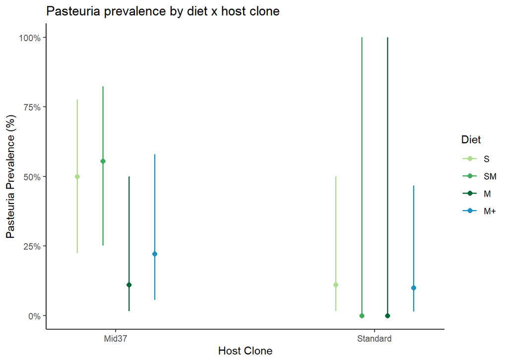

```r
# Marginal effects from best model with Abundance on the x axis
past_prev <- ggpredict(pprevmod, c("Clone", "Diet"))

# set the color scheme for the Diet treatments
diet_colors <- c("#ADDD8E", "#41AB5D", "#006837", "#1D91C0")

p_prev_fig <- plot(past_prev, dodge = 0.4) +
  scale_color_manual(values = diet_colors) +
  ggtitle("Pasteuria prevalence by diet x host clone") +
  labs(x = "Host Clone", y = "Pasteuria Prevalence (%)") +
  theme_classic()
p_prev_fig
```

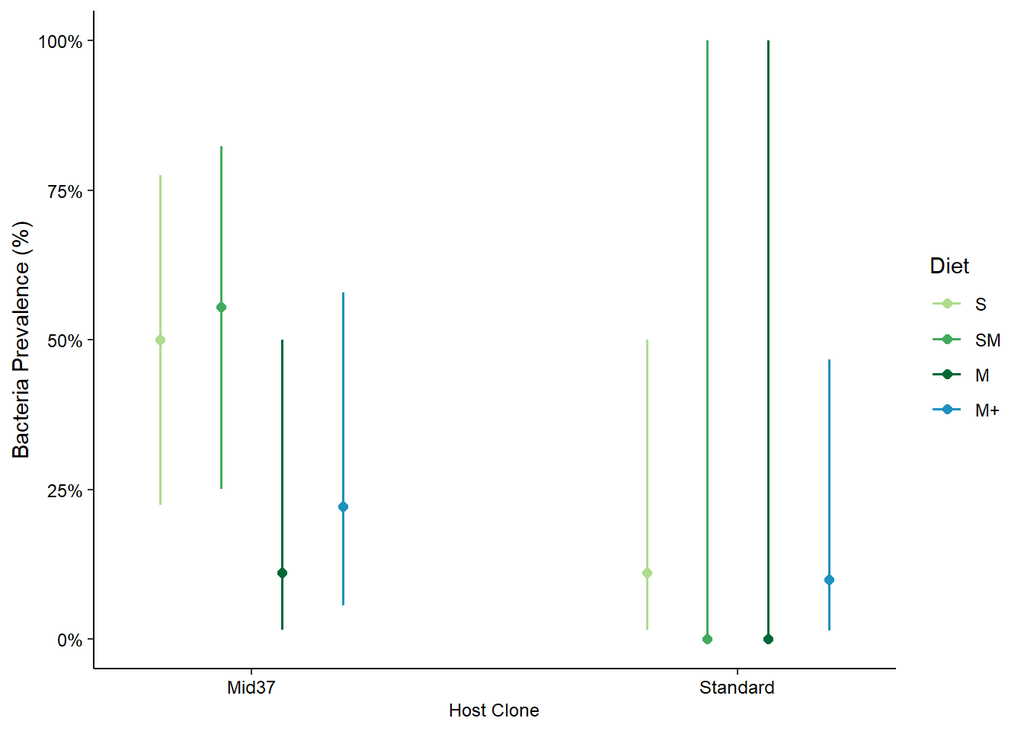

```r
# figures for presentation
p_prev_fig2 <- plot(past_prev, dodge = 0.5, show.title = F) +
  scale_color_manual(values = diet_colors) +
  #ggtitle("Pasteuria prevalence by diet x host clone") +
  labs(x = "Host Clone", y = "Bacteria Prevalence (%)") +
  theme_classic() +
  theme(axis.text = element_text(size=9, color = "black"), axis.title.y = element_text(size=11, color="black"),
        axis.title.x = element_text(size=9, color="black"))
p_prev_fig2
```

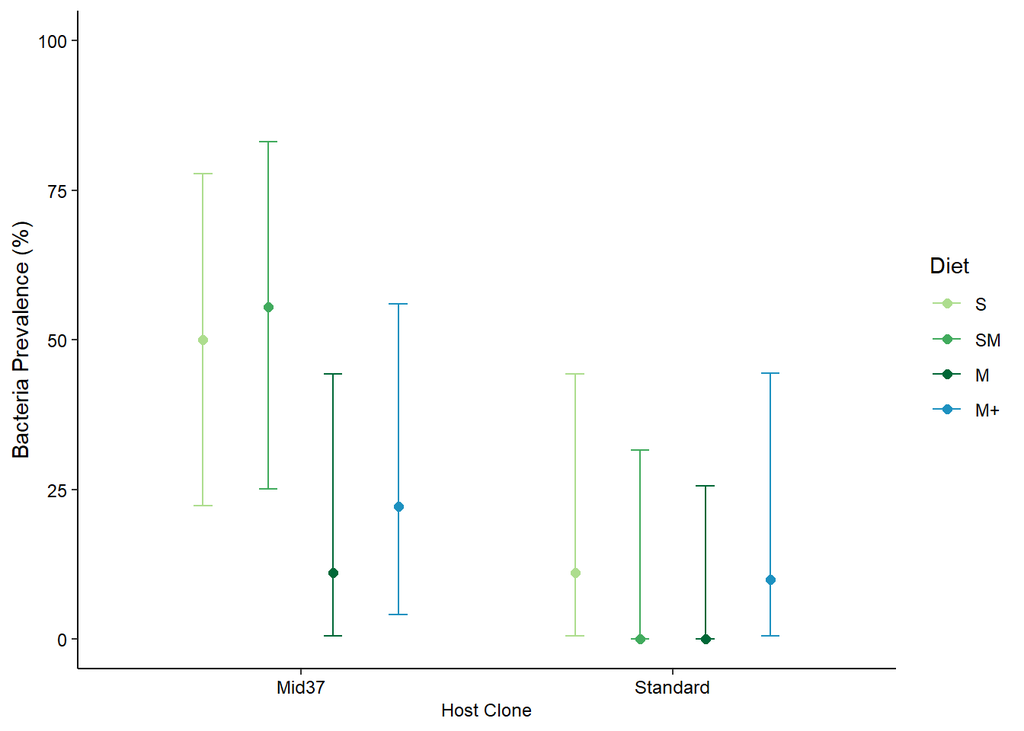

```r
ggsave("figures/PasteuriaPrev_DietxClone.tiff", plot = p_prev_fig2, dpi = 600, width = 4, height = 3, units = "in", compression="lzw")




# calculate prevalence for each diet and clone
p_data_prev$Rep <- as.character(p_data_prev$Rep)

past_prev_sum <- p_data_prev %>%
  group_by(Diet, Clone) %>%
  summarise(Infected = sum(InfectionStatus), Tested = length(Rep), .groups = "rowwise") %>%
  mutate(Prevalence = unlist(epi.prev(Infected, Tested, method = "blaker", conf.level = 0.95, sp = 1, se = 0.95))[1],
         Prev_Lower = unlist(epi.prev(Infected, Tested, method = "blaker", conf.level = 0.95, sp = 1, se = 0.95))[2],
         Prev_Upper = unlist(epi.prev(Infected, Tested, method = "blaker", conf.level = 0.95, sp = 1, se = 0.95))[3])

# figures for presentation
p_prev_fig3 <- ggplot(past_prev_sum, aes(x = Clone, y= Prevalence)) +
  geom_point(aes(color = Diet), size = 2, position = position_dodge(width = 0.7)) +
  geom_errorbar(aes(ymin = Prev_Lower, ymax = Prev_Upper, color = Diet), width = 0.2, position = position_dodge(width = 0.7)) +
  scale_color_manual(values = diet_colors) +
  labs(x = "Host Clone", y = "Bacteria Prevalence (%)") +
  ylim(0, 100) +
  theme_classic() +
  theme(axis.text = element_text(size=9, color = "black"), axis.title.y = element_text(size=11, color="black"),
        axis.title.x = element_text(size=9, color="black"))
p_prev_fig3
```

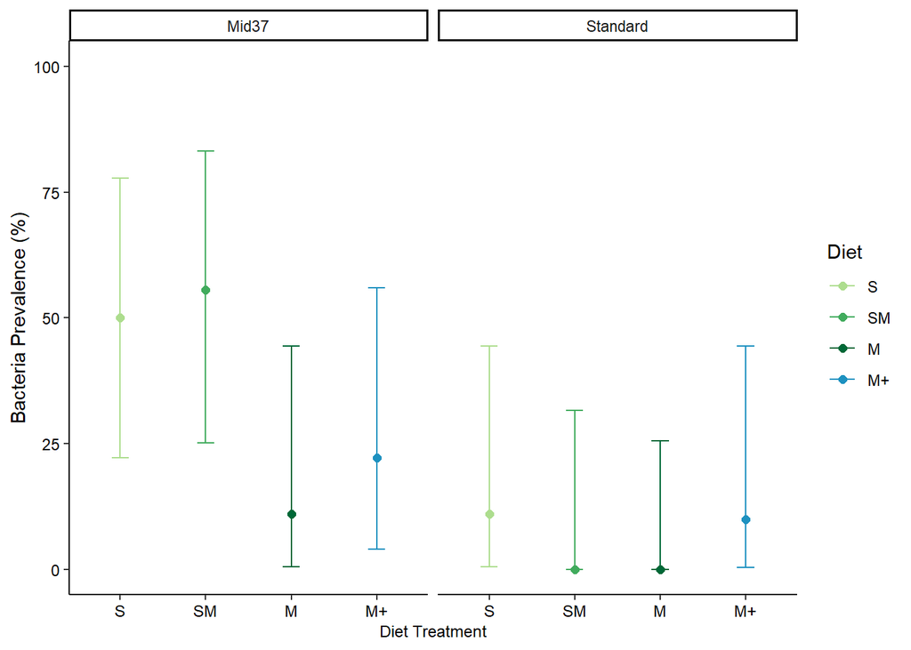

```r
p_prev_fig3 <- ggplot(past_prev_sum, aes(x = Diet, y= Prevalence)) +
  geom_point(aes(color = Diet), size = 2) +
  geom_errorbar(aes(ymin = Prev_Lower, ymax = Prev_Upper, color = Diet), width = 0.2) +
  scale_color_manual(values = diet_colors) +
  labs(x = "Diet Treatment", y = "Bacteria Prevalence (%)") +
  ylim(0, 100) +
  facet_wrap(~Clone) +
  theme_classic() +
  theme(axis.text = element_text(size=9, color = "black"), axis.title.y = element_text(size=11, color="black"),
        axis.title.x = element_text(size=9, color="black"))
p_prev_fig3
```

```r
ggsave("figures/PasteuriaPrevCalcualtions_DietxClone.tiff", plot = p_prev_fig3, dpi = 600, width = 4, height = 3, units = "in", compression="lzw")
```

There is a significant difference in prevalence based on clone, but not based on diet nor the interaction between the two. Standards were generally more resistant to this strain of Pasteuria compared to Mid37s. For Mid37s, there is lower Pasteuria prevalence for the M and M+ treatments, but it is not a significant difference. Maybe since we only have the 10 reps, our prevalence has rather large error bars.

In comparison with Kristel’s 2019 Proc B paper, we had lower Pasteuria infection in the mid37s overall, but also may have a greater difference between the Scenedesmus diet and the Microcystis and spiked Microcystis diets (note that we use different stains of Microcystis though).

### Comparison of Metsch infection prevalence based on diet, and host clone.

```r
m_data_prev <- m_data %>% filter(!is.na(InfectionStatus) & Parasites == "Metsch") # remove animals that died during exposure and remove uninfected treatments

m_data_prev$Block <- as.factor(m_data_prev$Block)

mprevmod <- glm(InfectionStatus ~ Diet * Clone, family = binomial, data = m_data_prev)
# Note: left off the block random effect here since it seemed to cause a problem with the model...
summary(mprevmod)
```

```
##
## Call:
## glm(formula = InfectionStatus ~ Diet * Clone, family = binomial,
##     data = m_data_prev)
##
## Deviance Residuals:
##      Min        1Q    Median        3Q       Max
## -1.84648  -0.35927  -0.00005  -0.00005   2.35482
##
## Coefficients:
##                       Estimate Std. Error z value Pr(>|z|)
## (Intercept)             1.5041     0.7817   1.924  0.05435 .
## DietSM                 -3.8067     1.3081  -2.910  0.00361 **
## DietM                 -22.0701  4738.6407  -0.005  0.99628
## DietM+                -22.0701  4300.2464  -0.005  0.99591
## CloneStandard          19.0620  5118.3170   0.004  0.99703
## DietSM:CloneStandard  -18.2635  5118.3171  -0.004  0.99715
## DietM:CloneStandard   -19.0620  9142.2886  -0.002  0.99834
## DietM+:CloneStandard   -1.2040  6685.0047   0.000  0.99986
## ---
## Signif. codes:  0 '***' 0.001 '**' 0.01 '*' 0.05 '.' 0.1 ' ' 1
##
## (Dispersion parameter for binomial family taken to be 1)
##
##     Null deviance: 113.039  on 100  degrees of freedom
## Residual deviance:  35.045  on  93  degrees of freedom
## AIC: 51.045
##
## Number of Fisher Scoring iterations: 19
```

```r
Anova(mprevmod)
```

```
## Analysis of Deviance Table (Type II tests)
##
## Response: InfectionStatus
##            LR Chisq Df Pr(>Chisq)
## Diet         74.276  3   5.18e-16 ***
## Clone         3.393  1    0.06546 .
## Diet:Clone    1.639  3    0.65052
## ---
## Signif. codes:  0 '***' 0.001 '**' 0.01 '*' 0.05 '.' 0.1 ' ' 1
```

```r
overdisp_fun(mprevmod)
```

```
##      chisq      ratio        rdf          p
## 49.0000001  0.5268817 93.0000000  0.9999514
```

```r
AIC(mprevmod)
```

```
## [1] 51.04546
```

```r
mprevmod_contrasts <- emmeans(mprevmod, specs = pairwise ~ Diet | Clone, type = "response")
mprevmod_contrasts
```

```
## $emmeans
## Clone = Mid37:
##  Diet      prob         SE  df asymp.LCL asymp.UCL
##  S    0.8181818 0.11629130 Inf 0.4929762  0.954185
##  SM   0.0909091 0.08667842 Inf 0.0126394  0.438572
##  M    0.0000000 0.00000555 Inf 0.0000000  1.000000
##  M+   0.0000000 0.00000503 Inf 0.0000000  1.000000
##
## Clone = Standard:
##  Diet      prob         SE  df asymp.LCL asymp.UCL
##  S    1.0000000 0.00000599 Inf 0.0000000  1.000000
##  SM   0.1818182 0.11629130 Inf 0.0458148  0.507024
##  M    0.0000000 0.00000692 Inf 0.0000000  1.000000
##  M+   0.0625000 0.06051536 Inf 0.0087294  0.335412
##
## Confidence level used: 0.95
## Intervals are back-transformed from the logit scale
##
## $contrasts
## Clone = Mid37:
##  contrast  odds.ratio       SE  df null z.ratio p.value
##  S / SM      4.50e+01 5.90e+01 Inf    1   2.910  0.0189
##  S / M       3.85e+09 1.82e+13 Inf    1   0.005  1.0000
##  S / (M+)    3.85e+09 1.65e+13 Inf    1   0.005  1.0000
##  SM / M      8.55e+07 4.05e+11 Inf    1   0.004  1.0000
##  SM / (M+)   8.55e+07 3.67e+11 Inf    1   0.004  1.0000
##  M / (M+)    1.00e+00 6.40e+03 Inf    1   0.000  1.0000
##
## Clone = Standard:
##  contrast  odds.ratio       SE  df null z.ratio p.value
##  S / SM      3.85e+09 1.97e+13 Inf    1   0.004  1.0000
##  S / M       7.30e+17 5.71e+21 Inf    1   0.005  1.0000
##  S / (M+)    1.28e+10 6.56e+13 Inf    1   0.005  1.0000
##  SM / M      1.90e+08 1.12e+12 Inf    1   0.003  1.0000
##  SM / (M+)   3.00e+00 4.00e+00 Inf    1   0.930  0.7890
##  M / (M+)    0.00e+00 0.00e+00 Inf    1  -0.003  1.0000
##
## P value adjustment: tukey method for comparing a family of 4 estimates
## Tests are performed on the log odds ratio scale
```

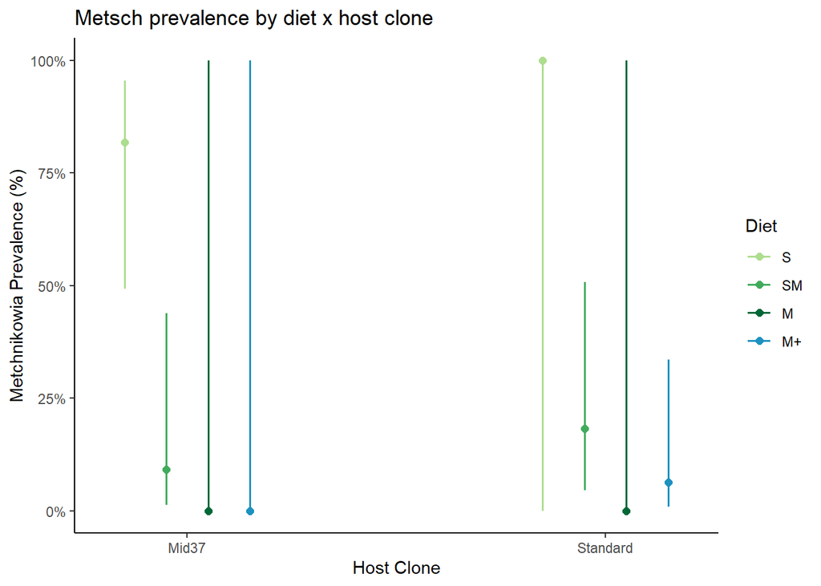

```r
# Marginal effects from best model with Abundance on the x axis
metsch_prev <- ggpredict(mprevmod, c("Clone", "Diet"))

m_prev_fig <- plot(metsch_prev, dodge = 0.4) +
  scale_color_manual(values = diet_colors) +
  ggtitle("Metsch prevalence by diet x host clone") +
  labs(x = "Host Clone", y = "Metchnikowia Prevalence (%)") +
  theme_classic()
m_prev_fig
```

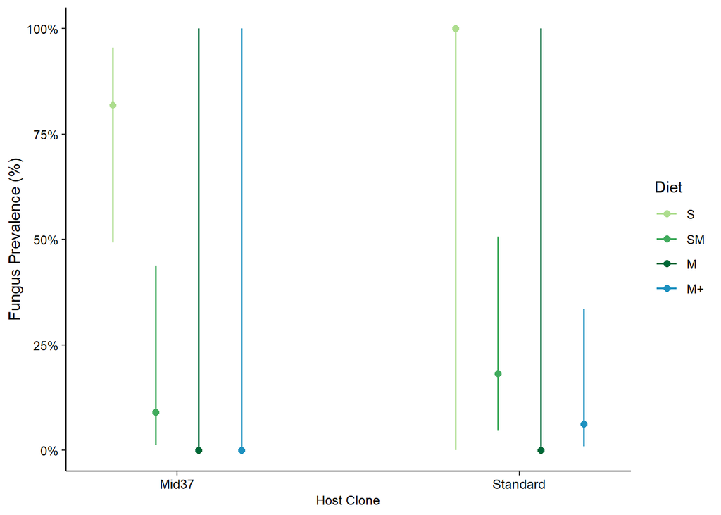

```r
# figure for presentation
m_prev_fig2 <- plot(metsch_prev, dodge = 0.5, show.title = F) +
  scale_color_manual(values = diet_colors) +
  #ggtitle("Metsch prevalence by diet x host clone") +
  labs(x = "Host Clone", y = "Fungus Prevalence (%)") +
  theme_classic() +
  theme(axis.text = element_text(size=9, color = "black"), axis.title.y = element_text(size=11, color="black"),
        axis.title.x = element_text(size=9, color="black"))
m_prev_fig2
```

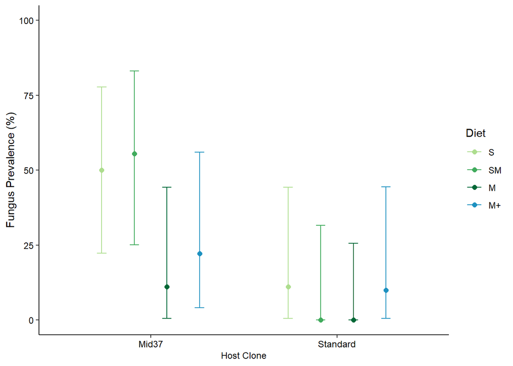

```r
ggsave("figures/MetschPrev_DietxClone.tiff", plot = m_prev_fig2, dpi = 600, width = 4, height = 3, units = "in", compression="lzw")




# calculate prevalence for each diet and clone
m_data_prev$Rep <- as.character(m_data_prev$Rep)

metsch_prev_sum <- m_data_prev %>%
  group_by(Diet, Clone) %>%
  summarise(Infected = sum(InfectionStatus), Tested = length(Rep), .groups = "rowwise") %>%
  mutate(Prevalence = unlist(epi.prev(Infected, Tested, method = "blaker", conf.level = 0.95, sp = 1, se = 0.95))[1],
         Prev_Lower = unlist(epi.prev(Infected, Tested, method = "blaker", conf.level = 0.95, sp = 1, se = 0.95))[2],
         Prev_Upper = unlist(epi.prev(Infected, Tested, method = "blaker", conf.level = 0.95, sp = 1, se = 0.95))[3])
# figures for presentation
m_prev_fig3 <- ggplot(past_prev_sum, aes(x = Clone, y= Prevalence)) +
  geom_point(aes(color = Diet), size = 2, position = position_dodge(width = 0.7)) +
  geom_errorbar(aes(ymin = Prev_Lower, ymax = Prev_Upper, color = Diet), width = 0.2, position = position_dodge(width = 0.7)) +
  scale_color_manual(values = diet_colors) +
  labs(x = "Host Clone", y = "Fungus Prevalence (%)") +
  ylim(0, 100) +
  theme_classic() +
  theme(axis.text = element_text(size=9, color = "black"), axis.title.y = element_text(size=11, color="black"),
        axis.title.x = element_text(size=9, color="black"))
m_prev_fig3
```

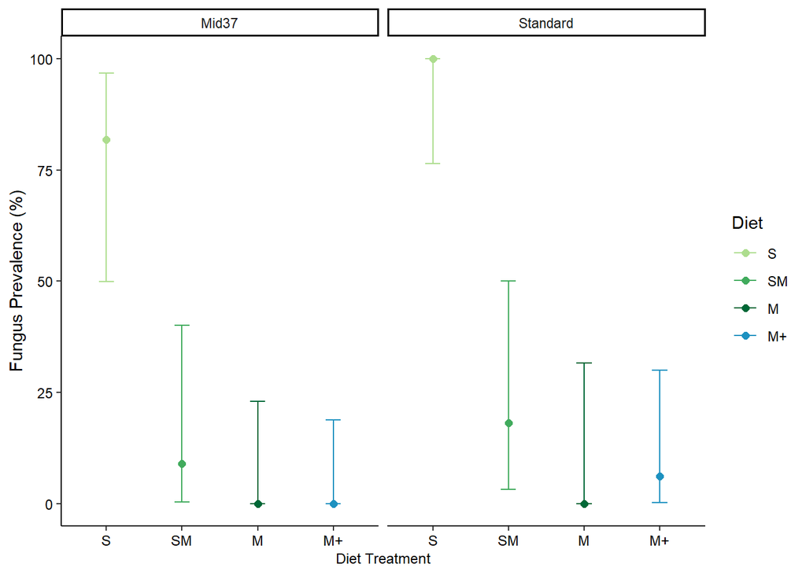

```r
m_prev_fig3 <- ggplot(metsch_prev_sum, aes(x = Diet, y= Prevalence)) +
  geom_point(aes(color = Diet), size = 2) +
  geom_errorbar(aes(ymin = Prev_Lower, ymax = Prev_Upper, color = Diet), width = 0.2) +
  scale_color_manual(values = diet_colors) +
  labs(x = "Diet Treatment", y = "Fungus Prevalence (%)") +
  ylim(0, 100) +
  facet_wrap(~Clone) +
  theme_classic() +
  theme(axis.text = element_text(size=9, color = "black"), axis.title.y = element_text(size=11, color="black"),
        axis.title.x = element_text(size=9, color="black"))
m_prev_fig3
```

```r
ggsave("figures/MetschPrevCalcualtions_DietxClone.tiff", plot = m_prev_fig3, dpi = 600, width = 4, height = 3, units = "in", compression="lzw")
```

In comparison to Kristel’s 2019 Proc B paper, we similarly see a large decrease in infection prevalence when comparing the high quality Scenedesmus diet to the low quality Micorcystis diet. We don’t see much of a change in infection prevalence between the Microcystis and the toxin spiked Microcosytis treatments though.

## Spore Yield

### Comparison of Total Pasteuria spore yield based on diet and host clone.

```r
# remove animals that died during exposure and remove uninfected treatments and remove animals with no spores detected
p_data_spores <- p_data %>% filter(!is.na(InfectionStatus) & Parasites == "Pasteuria" & total_spores > 0)


ptotsporemod <- lmer(log(total_spores) ~ Diet * Clone + (1|Block), data = p_data_spores)
summary(ptotsporemod)
```

```
## Linear mixed model fit by REML. t-tests use Satterthwaite's method [
## lmerModLmerTest]
## Formula: log(total_spores) ~ Diet * Clone + (1 | Block)
##    Data: p_data_spores
##
## REML criterion at convergence: 74.1
##
## Scaled residuals:
##      Min       1Q   Median       3Q      Max
## -1.40777 -0.51405  0.07215  0.26798  2.04181
##
## Random effects:
##  Groups   Name        Variance Std.Dev.
##  Block    (Intercept) 0.530    0.728
##  Residual             4.766    2.183
## Number of obs: 23, groups:  Block, 2
##
## Fixed effects:
##                      Estimate Std. Error      df t value Pr(>|t|)
## (Intercept)           11.3476     1.1279  3.2959  10.061  0.00138 **
## DietSM                 0.3884     1.3807 14.0000   0.281  0.78256
## DietM                 -2.4143     1.9289 13.9419  -1.252  0.23129
## DietM+                -1.1790     1.8412 14.5114  -0.640  0.53191
## CloneStandard         -3.5975     1.5976 14.1487  -2.252  0.04073 *
## DietSM:CloneStandard  -2.4065     2.4381 14.3763  -0.987  0.33994
## DietM:CloneStandard    0.5401     3.2345 14.7867   0.167  0.86966
## DietM+:CloneStandard   0.9234     2.5626 14.2832   0.360  0.72387
## ---
## Signif. codes:  0 '***' 0.001 '**' 0.01 '*' 0.05 '.' 0.1 ' ' 1
##
## Correlation of Fixed Effects:
##             (Intr) DietSM DietM  DietM+ ClnStn DSM:CS DtM:CS
## DietSM      -0.612
## DietM       -0.504  0.358
## DietM+      -0.485  0.375  0.309
## CloneStndrd -0.542  0.432  0.330  0.332
## DtSM:ClnStn  0.368 -0.566 -0.237 -0.226 -0.659
## DtM:ClnStnd  0.317 -0.213 -0.622 -0.194 -0.509  0.351
## DtM+:ClnStn  0.348 -0.269 -0.222 -0.718 -0.627  0.416  0.331
```

```r
Anova(ptotsporemod)
```

```
## Analysis of Deviance Table (Type II Wald chisquare tests)
##
## Response: log(total_spores)
##              Chisq Df Pr(>Chisq)
## Diet        2.2469  3     0.5228
## Clone      16.8973  1  3.946e-05 ***
## Diet:Clone  1.8331  3     0.6078
## ---
## Signif. codes:  0 '***' 0.001 '**' 0.01 '*' 0.05 '.' 0.1 ' ' 1
```

```r
AIC(ptotsporemod)
```

```
## [1] 94.0521
```

```r
ptotsporemod_contrasts <- emmeans(ptotsporemod, specs = pairwise ~ Diet | Clone, type = "response")
ptotsporemod_contrasts
```

```
## $emmeans
## Clone = Mid37:
##  Diet response     SE    df lower.CL upper.CL
##  S       84763 106402  3.30  1897.24  3786966
##  SM     124998 156907  3.30  2797.80  5584531
##  M        7581  14465  8.36    96.12   597846
##  M+      26071  42422 10.45   709.28   958275
##
## Clone = Standard:
##  Diet response     SE    df lower.CL upper.CL
##  S        2322   3254  6.85    83.19    64801
##  SM        309    589  8.36     3.91    24338
##  M         356    875 13.29     1.80    70718
##  M+       1798   2520  6.85    64.42    50182
##
## Degrees-of-freedom method: kenward-roger
## Confidence level used: 0.95
## Intervals are back-transformed from the log scale
##
## $contrasts
## Clone = Mid37:
##  contrast   ratio     SE   df null t.ratio p.value
##  S / SM     0.678  0.936 14.0    1  -0.281  0.9919
##  S / M     11.182 27.112 13.9    1   0.996  0.7543
##  S / (M+)   3.251  6.248 14.5    1   0.613  0.9261
##  SM / M    16.489 39.981 13.9    1   1.156  0.6628
##  SM / (M+)  4.795  9.214 14.5    1   0.816  0.8462
##  M / (M+)   0.291  0.698 14.8    1  -0.515  0.9543
##
## Clone = Standard:
##  contrast   ratio     SE   df null t.ratio p.value
##  S / SM     7.524 15.805 14.5    1   0.961  0.7732
##  S / M      6.516 16.985 14.3    1   0.719  0.8880
##  S / (M+)   1.291  2.302 14.0    1   0.143  0.9989
##  SM / M     0.866  2.315 14.0    1  -0.054  0.9999
##  SM / (M+)  0.172  0.361 14.5    1  -0.839  0.8352
##  M / (M+)   0.198  0.517 14.3    1  -0.621  0.9237
##
## Degrees-of-freedom method: kenward-roger
## P value adjustment: tukey method for comparing a family of 4 estimates
## Tests are performed on the log scale
```

```r
# Marginal effects from best model with Abundance on the x axis
past_totspores <- ggpredict(ptotsporemod, c("Clone", "Diet"))
```

```
## Model has log-transformed response. Back-transforming predictions to
##   original response scale. Standard errors are still on the log-scale.
```

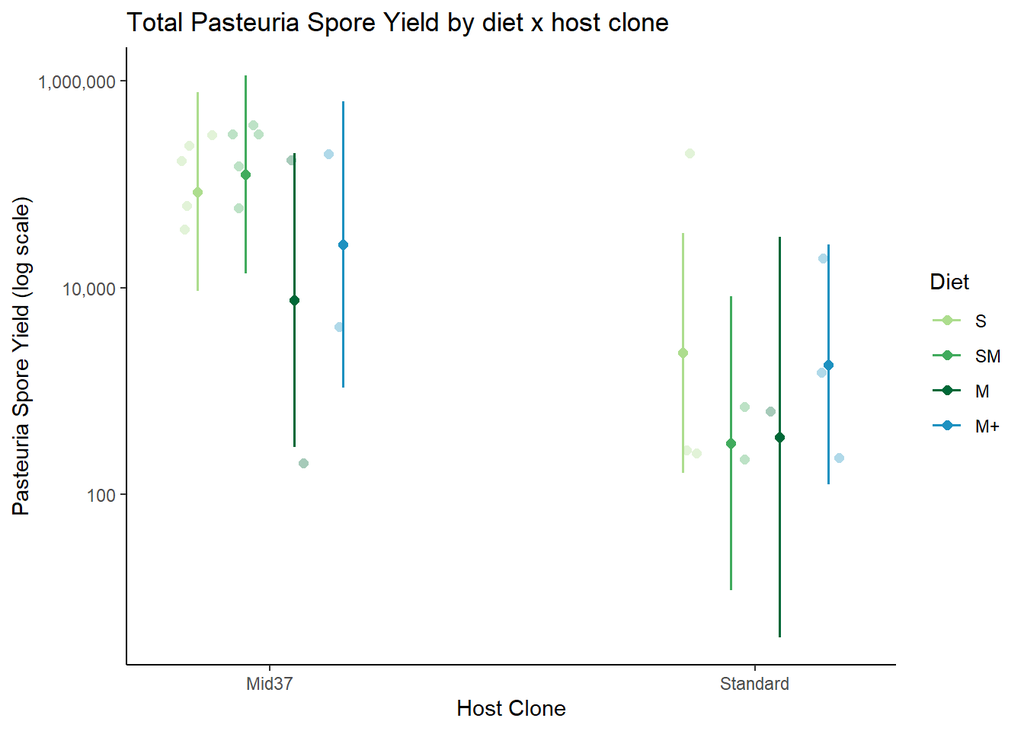

```r
p_totspore_fig <- plot(past_totspores, dodge = 0.4, add.data = T) +
  scale_color_manual(values = diet_colors) +
  ggtitle("Total Pasteuria Spore Yield by diet x host clone") +
  labs(x = "Host Clone", y = "Pasteuria Spore Yield (log scale)") +
  scale_y_log10(labels = scales::comma) +
  theme_classic()
p_totspore_fig
```

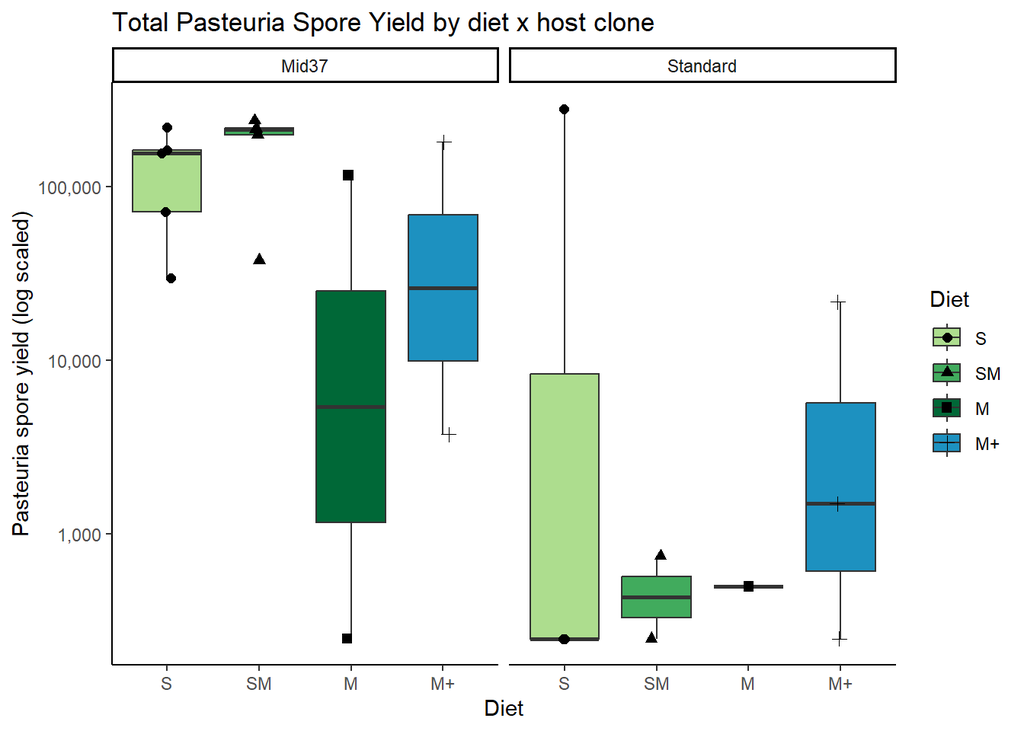

```r
p_totspore_fig2 <- ggplot(p_data_spores, aes(x = Diet, y = total_spores)) +
  geom_boxplot(aes(fill=Diet),position=position_dodge()) +
  geom_point(aes(shape=Diet), size=2, position=position_jitterdodge()) +
  facet_wrap(~Clone) +
  scale_fill_discrete(limits = c("S", "SM", "M", "M+")) +
  scale_shape_discrete(limits = c("S", "SM", "M", "M+")) +
  scale_fill_manual(values = diet_colors) +
  ylim(0,300000) +
  scale_y_log10(labels = scales::comma) +
  ggtitle("Total Pasteuria Spore Yield by diet x host clone") +
  labs(x = "Diet", y = "Pasteuria spore yield (log scaled)") +
  theme_classic()
p_totspore_fig2
```

**Question 1:** Is this data better represented by the ggeffects plot (top) or the boxplot (bottom)? It is possible that the standard error in the top plot is larger than it should be because the point has been back transformed from the log transformation, but I’m not sure that the standard error was as well based on one of the error messages…

**Question 2:** This data includes animals that I only saw one or two spores in the entire count (mostly in Standard treatments). I did not count those animals as infected in the prevalence data above because although I found a spore present, they did not appear infected in photos and the count was so low that I did not consider it a full infection. Should those very low spore counts be included in this analysis or should we have a cut off threshold for the spore yield that is needed to be included?

### Comparison of Mature Pasteuria spore yield based on diet and host clone.

Note that there is one standard animal that had zero mature spores but did have one immature spore detected in the S treatment, which is included in this data set.

```r
pmaturesporemod <- lmer(log(mature_spores+1) ~ Diet * Clone + (1|Block), data = p_data_spores)
```

```
## boundary (singular) fit: see help('isSingular')
```

```r
summary(pmaturesporemod)
```

```
## Linear mixed model fit by REML. t-tests use Satterthwaite's method [
## lmerModLmerTest]
## Formula: log(mature_spores + 1) ~ Diet * Clone + (1 | Block)
##    Data: p_data_spores
##
## REML criterion at convergence: 80.7
##
## Scaled residuals:
##      Min       1Q   Median       3Q      Max
## -2.13391 -0.31206  0.07528  0.17189  2.28090
##
## Random effects:
##  Groups   Name        Variance Std.Dev.
##  Block    (Intercept) 0.000    0.000
##  Residual             7.734    2.781
## Number of obs: 23, groups:  Block, 2
##
## Fixed effects:
##                      Estimate Std. Error      df t value Pr(>|t|)
## (Intercept)           11.3439     1.2437 15.0000   9.121 1.65e-07 ***
## DietSM                 0.4785     1.7588 15.0000   0.272   0.7893
## DietM                 -2.7703     2.3267 15.0000  -1.191   0.2523
## DietM+                -1.2222     2.3267 15.0000  -0.525   0.6071
## CloneStandard         -5.4097     2.0309 15.0000  -2.664   0.0177 *
## DietSM:CloneStandard  -0.3393     3.0884 15.0000  -0.110   0.9140
## DietM:CloneStandard    3.0526     3.9655 15.0000   0.770   0.4534
## DietM+:CloneStandard   2.8647     3.2510 15.0000   0.881   0.3921
## ---
## Signif. codes:  0 '***' 0.001 '**' 0.01 '*' 0.05 '.' 0.1 ' ' 1
##
## Correlation of Fixed Effects:
##             (Intr) DietSM DietM  DietM+ ClnStn DSM:CS DtM:CS
## DietSM      -0.707
## DietM       -0.535  0.378
## DietM+      -0.535  0.378  0.286
## CloneStndrd -0.612  0.433  0.327  0.327
## DtSM:ClnStn  0.403 -0.569 -0.215 -0.215 -0.658
## DtM:ClnStnd  0.314 -0.222 -0.587 -0.168 -0.512  0.337
## DtM+:ClnStn  0.383 -0.271 -0.204 -0.716 -0.625  0.411  0.320
## optimizer (nloptwrap) convergence code: 0 (OK)
## boundary (singular) fit: see help('isSingular')
```

```r
Anova(pmaturesporemod)
```

```
## Analysis of Deviance Table (Type II Wald chisquare tests)
##
## Response: log(mature_spores + 1)
##              Chisq Df Pr(>Chisq)
## Diet        1.3836  3  0.7093905
## Clone      13.2086  1  0.0002787 ***
## Diet:Clone  1.4757  3  0.6878904
## ---
## Signif. codes:  0 '***' 0.001 '**' 0.01 '*' 0.05 '.' 0.1 ' ' 1
```

```r
AIC(pmaturesporemod)
```

```
## [1] 100.7472
```

```r
pmaturesporemod_contrasts <- emmeans(pmaturesporemod, specs = pairwise ~ Diet | Clone, type = "response")
pmaturesporemod_contrasts
```

```
## $emmeans
## Clone = Mid37:
##  Diet response     SE    df lower.CL upper.CL
##  S       84447 131249  3.80 1027.818  6931724
##  SM     136267 211787  3.80 1659.132 11185240
##  M        5289  13257  8.28   15.929  1653162
##  M+      24877  48921 13.63  361.693  1706451
##
## Clone = Standard:
##  Diet response     SE    df lower.CL upper.CL
##  S         377    637 10.01    7.811    16194
##  SM        433   1088  8.28    0.389   135673
##  M         500   1596 13.63   -0.469   472558
##  M+       1951   3294 10.01   44.536    83701
##
## Degrees-of-freedom method: kenward-roger
## Confidence level used: 0.95
## Intervals are back-transformed from the log(mu + 1) scale
##
## $contrasts
## Clone = Mid37:
##  contrast   ratio     SE    df null t.ratio p.value
##  S / SM     0.620  1.090 14.00    1  -0.272  0.9926
##  S / M     15.963 54.349  9.14    1   0.814  0.8466
##  S / (M+)   3.394  8.508 14.80    1   0.488  0.9607
##  SM / M    25.758 87.698  9.14    1   0.954  0.7775
##  SM / (M+)  5.477 13.729 14.80    1   0.679  0.9036
##  M / (M+)   0.213  0.677 14.99    1  -0.486  0.9610
##
## Clone = Standard:
##  contrast   ratio     SE    df null t.ratio p.value
##  S / SM     0.870  2.385 14.82    1  -0.051  1.0000
##  S / M      0.754  2.544 14.58    1  -0.084  0.9998
##  S / (M+)   0.193  0.439 14.00    1  -0.723  0.8861
##  SM / M     0.867  2.952 14.00    1  -0.042  1.0000
##  SM / (M+)  0.222  0.610 14.82    1  -0.548  0.9456
##  M / (M+)   0.257  0.866 14.58    1  -0.403  0.9770
##
## Degrees-of-freedom method: kenward-roger
## P value adjustment: tukey method for comparing a family of 4 estimates
## Tests are performed on the log scale
```

```r
# Marginal effects from best model with Abundance on the x axis
past_maturespores <- ggpredict(pmaturesporemod, c("Clone", "Diet"))
```

```
## Could not compute variance-covariance matrix of predictions. No confidence intervals are returned.
```

```
## Model has log-transformed response. Back-transforming predictions to
##   original response scale. Standard errors are still on the log-scale.
```

```r
p_maturespore_fig <- plot(past_maturespores, dodge = 0.4, add.data = T) +
  scale_color_manual(values = diet_colors) +
  ggtitle("Mature Pasteuria Spore Yield by diet x host clone") +
  labs(x = "Host Clone", y = "Pasteuria Spore Yield (log scale)") +
  scale_y_log10(labels = scales::comma) +
  theme_classic()
```

```
## Raw data not available.
```

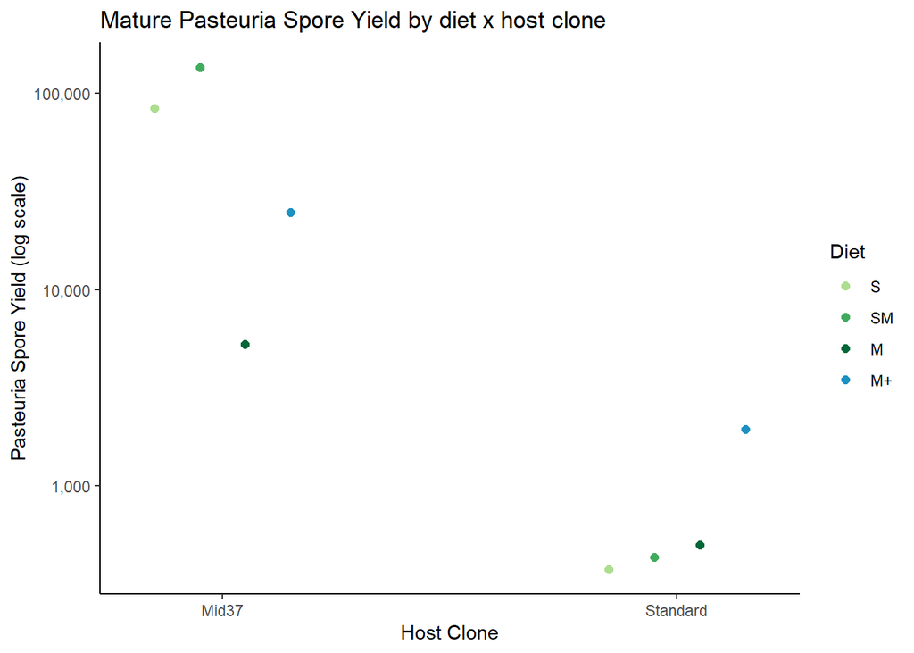

```r
p_maturespore_fig
```

```r
# figure for presentation
p_maturespore_fig3 <- plot(past_maturespores, dodge = 0.5, add.data = T, show.title = F) +
  scale_color_manual(values = diet_colors) +
  #ggtitle("Mature Pasteuria Spore Yield by diet x host clone") +
  labs(x = "Host Clone", y = "Mature Bacteria Spore Yield (log scale)") +
  scale_y_log10(labels = scales::comma) +
  theme_classic() +
  theme(axis.text = element_text(size=9, color = "black"), axis.title.y = element_text(size=11, color="black"),
        axis.title.x = element_text(size=9, color="black"))
```

```
## Raw data not available.
```

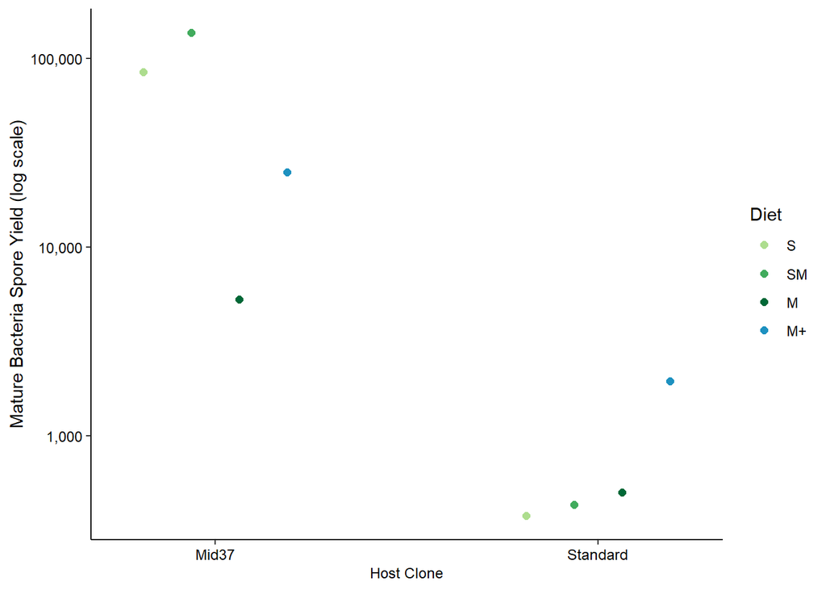

```r
p_maturespore_fig3
```

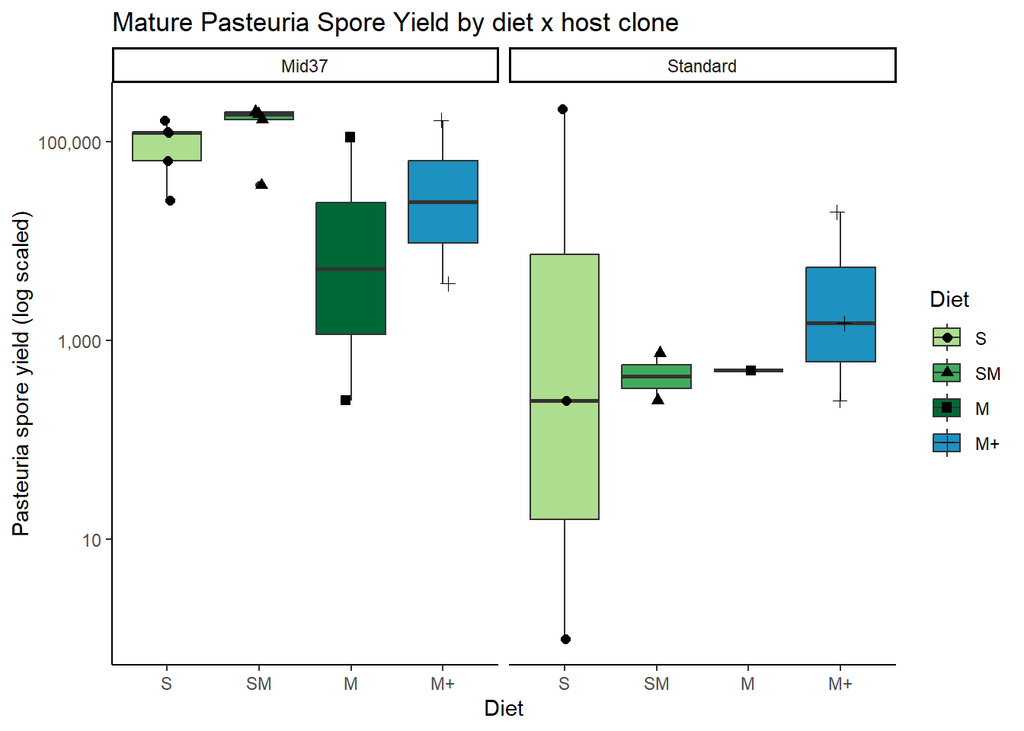

```r
ggsave("figures/PastMatureSpores_DietxClone.tiff", plot = p_maturespore_fig3, dpi = 600, width = 4, height = 3, units = "in", compression="lzw")



p_maturespore_fig2 <- ggplot(p_data_spores, aes(x = Diet, y = mature_spores+1)) +
  geom_boxplot(aes(fill=Diet),position=position_dodge()) +
  geom_point(aes(shape=Diet), size=2, position=position_jitterdodge()) +
  facet_wrap(~Clone) +
  scale_fill_discrete(limits = c("S", "SM", "M", "M+")) +
  scale_shape_discrete(limits = c("S", "SM", "M", "M+")) +
  scale_fill_manual(values = diet_colors) +
  ylim(0,300000) +
  scale_y_log10(labels = scales::comma) +
  ggtitle("Mature Pasteuria Spore Yield by diet x host clone") +
  labs(x = "Diet", y = "Pasteuria spore yield (log scaled)") +
  theme_classic()
p_maturespore_fig2
```

### Comparison of Immature Pasteuria spore yield based on diet and host clone.

```r
pimmaturesporemod <- lmer(log(immature_spores+1) ~ Diet * Clone + (1|Block), data = p_data_spores)
summary(pimmaturesporemod)
```

```
## Linear mixed model fit by REML. t-tests use Satterthwaite's method [
## lmerModLmerTest]
## Formula: log(immature_spores + 1) ~ Diet * Clone + (1 | Block)
##    Data: p_data_spores
##
## REML criterion at convergence: 86.9
##
## Scaled residuals:
##     Min      1Q  Median      3Q     Max
## -1.3206 -0.3869  0.0000  0.2488  1.3982
##
## Random effects:
##  Groups   Name        Variance Std.Dev.
##  Block    (Intercept)  5.937   2.437
##  Residual             10.519   3.243
## Number of obs: 23, groups:  Block, 2
##
## Fixed effects:
##                      Estimate Std. Error      df t value Pr(>|t|)
## (Intercept)            8.8881     2.3004  1.9267   3.864   0.0646 .
## DietSM                -0.3701     2.0513 14.0000  -0.180   0.8594
## DietM                 -3.0688     2.9870 14.8884  -1.027   0.3206
## DietM+                -4.0402     2.7537 14.2000  -1.467   0.1641
## CloneStandard         -3.8580     2.3777 14.0547  -1.623   0.1269
## DietSM:CloneStandard  -6.1962     3.6393 14.1432  -1.703   0.1105
## DietM:CloneStandard   -3.4975     4.9515 14.7304  -0.706   0.4910
## DietM+:CloneStandard   1.0317     3.8204 14.1061   0.270   0.7910
## ---
## Signif. codes:  0 '***' 0.001 '**' 0.01 '*' 0.05 '.' 0.1 ' ' 1
##
## Correlation of Fixed Effects:
##             (Intr) DietSM DietM  DietM+ ClnStn DSM:CS DtM:CS
## DietSM      -0.446
## DietM       -0.391  0.343
## DietM+      -0.367  0.372  0.327
## CloneStndrd -0.402  0.431  0.333  0.336
## DtSM:ClnStn  0.280 -0.564 -0.253 -0.234 -0.661
## DtM:ClnStnd  0.257 -0.207 -0.647 -0.215 -0.508  0.362
## DtM+:ClnStn  0.264 -0.268 -0.236 -0.721 -0.628  0.421  0.340
```

```r
Anova(pimmaturesporemod)
```

```
## Analysis of Deviance Table (Type II Wald chisquare tests)
##
## Response: log(immature_spores + 1)
##              Chisq Df Pr(>Chisq)
## Diet        5.1314  3     0.1624
## Clone      15.5061  1  8.224e-05 ***
## Diet:Clone  4.2025  3     0.2404
## ---
## Signif. codes:  0 '***' 0.001 '**' 0.01 '*' 0.05 '.' 0.1 ' ' 1
```

```r
AIC(pimmaturesporemod)
```

```
## [1] 106.9461
```

```r
pimmaturesporemod_contrasts <- emmeans(pimmaturesporemod, specs = pairwise ~ Diet | Clone, type = "response")
pimmaturesporemod_contrasts
```

```
## $emmeans
## Clone = Mid37:
##  Diet response       SE   df lower.CL upper.CL
##  S    7244.321 1.70e+04 1.93   -0.801 2.63e+08
##  SM   5002.933 1.18e+04 1.93   -0.862 1.82e+08
##  M     335.728 1.04e+03 4.62   -0.900 1.14e+06
##  M+    126.479 3.66e+02 4.40   -0.942 2.78e+05
##
## Clone = Standard:
##  Diet response       SE   df lower.CL upper.CL
##  S     151.957 3.93e+02 2.93   -0.962 6.20e+05
##  SM     -0.785 6.64e-01 4.62   -1.000 7.27e+02
##  M      -0.785 8.27e-01 8.80   -1.000 1.32e+03
##  M+      6.551 1.94e+01 2.93   -0.998 3.06e+04
##
## Degrees-of-freedom method: kenward-roger
## Confidence level used: 0.95
## Intervals are back-transformed from the log(mu + 1) scale
##
## $contrasts
## Clone = Mid37:
##  contrast     ratio       SE   df null t.ratio p.value
##  S / SM      1.4479 2.97e+00 14.0    1   0.180  0.9978
##  S / M      21.5168 7.02e+01 14.9    1   0.941  0.7839
##  S / (M+)   56.8352 1.59e+02 14.2    1   1.444  0.4940
##  SM / M     14.8604 4.85e+01 14.9    1   0.827  0.8408
##  SM / (M+)  39.2529 1.10e+02 14.2    1   1.312  0.5705
##  M / (M+)    2.6414 9.07e+00 14.4    1   0.283  0.9918
##
## Clone = Standard:
##  contrast     ratio       SE   df null t.ratio p.value
##  S / SM    710.7678 2.17e+03 14.2    1   2.149  0.1850
##  S / M     710.7678 2.72e+03 14.1    1   1.719  0.3506
##  S / (M+)   20.2553 5.36e+01 14.0    1   1.136  0.6744
##  SM / M      1.0000 3.97e+00 14.0    1   0.000  1.0000
##  SM / (M+)   0.0285 8.71e-02 14.2    1  -1.164  0.6576
##  M / (M+)    0.0285 1.09e-01 14.1    1  -0.931  0.7888
##
## Degrees-of-freedom method: kenward-roger
## P value adjustment: tukey method for comparing a family of 4 estimates
## Tests are performed on the log scale
```

```r
# Marginal effects from best model with Abundance on the x axis
past_immaturespores <- ggpredict(pimmaturesporemod, c("Clone", "Diet"))
```

```
## Could not compute variance-covariance matrix of predictions. No confidence intervals are returned.
```

```
## Model has log-transformed response. Back-transforming predictions to
##   original response scale. Standard errors are still on the log-scale.
```

```r
p_immaturespore_fig <- plot(past_immaturespores, dodge = 0.4, add.data = T) +
  scale_color_manual(values = diet_colors) +
  ggtitle("Immature Pasteuria Spore Yield by diet x host clone") +
  labs(x = "Host Clone", y = "Immature Pasteuria Spore Yield (log scale)") +
  scale_y_log10(labels = scales::comma) +
  theme_classic()
```

```
## Raw data not available.
```

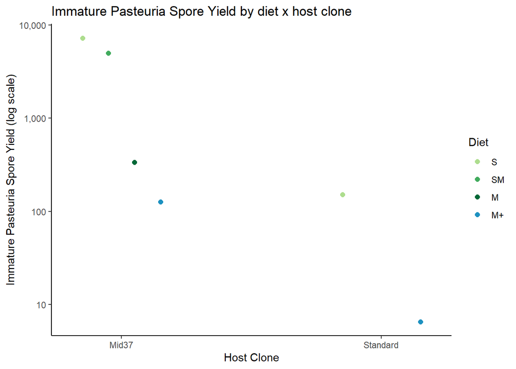

```r
p_immaturespore_fig
```

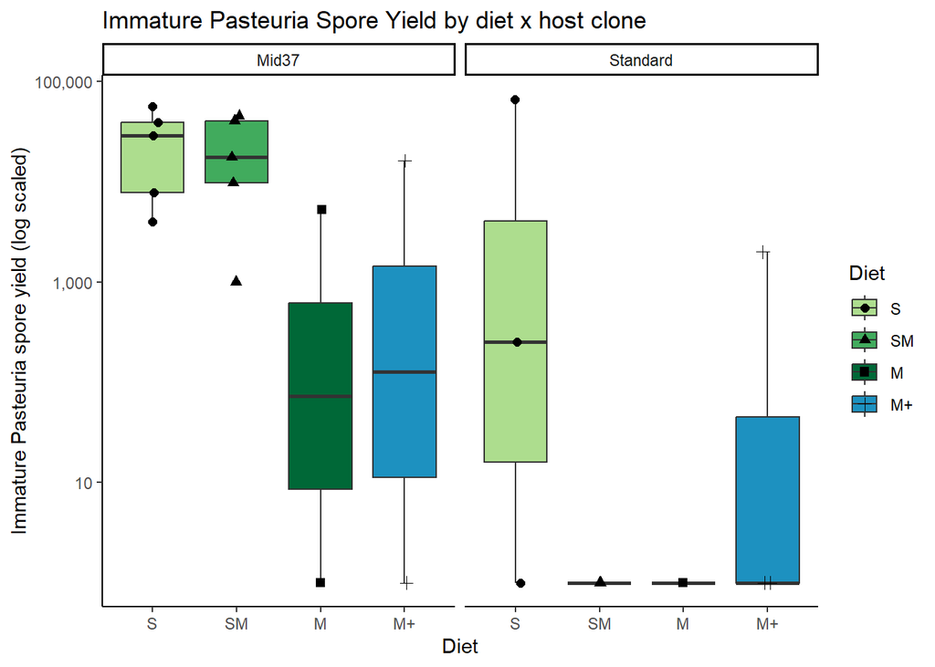

```r
p_immaturespore_fig2 <- ggplot(p_data_spores, aes(x = Diet, y = immature_spores+1)) +
  geom_boxplot(aes(fill=Diet),position=position_dodge()) +
  geom_point(aes(shape=Diet), size=2, position=position_jitterdodge()) +
  facet_wrap(~Clone) +
  scale_fill_discrete(limits = c("S", "SM", "M", "M+")) +
  scale_shape_discrete(limits = c("S", "SM", "M", "M+")) +
  scale_fill_manual(values = diet_colors) +
  ylim(0,300000) +
  scale_y_log10(labels = scales::comma) +
  ggtitle("Immature Pasteuria Spore Yield by diet x host clone") +
  labs(x = "Diet", y = "Immature Pasteuria spore yield (log scaled)") +
  theme_classic()
p_immaturespore_fig2
```

Overall there are many fewer immature spores compared to mature spores in the infected animals. There is very wide variation in the number of immature spores in M and M+ treatments in Mid37s. May want to think about which data to acutally keep in this data set since there are a lot of zeros…

I did not find any spores at the cauliflower stage.

### Comparison of Total Metsch spore yield based on diet and host clone.

```r
# remove animals that died during exposure and remove uninfected treatments and remove animals with no spores detected
m_data_spores <- m_data %>% filter(!is.na(InfectionStatus) & Parasites == "Metsch" & total_spores > 0)
#hist(m_data_spores$total_spores)

mtotsporemod <- lmer(log(total_spores) ~ Diet + Clone + (1|Block), data = m_data_spores)
summary(mtotsporemod)
```

```
## Linear mixed model fit by REML. t-tests use Satterthwaite's method [
## lmerModLmerTest]
## Formula: log(total_spores) ~ Diet + Clone + (1 | Block)
##    Data: m_data_spores
##
## REML criterion at convergence: 89
##
## Scaled residuals:
##     Min      1Q  Median      3Q     Max
## -2.6645 -0.2467  0.1670  0.5068  1.6820
##
## Random effects:
##  Groups   Name        Variance Std.Dev.
##  Block    (Intercept) 0.1779   0.4218
##  Residual             1.9824   1.4080
## Number of obs: 28, groups:  Block, 3
##
## Fixed effects:
##               Estimate Std. Error      df t value Pr(>|t|)
## (Intercept)    10.8559     0.5162  6.1955  21.031 5.37e-07 ***
## DietSM         -1.5826     0.7769 21.0732  -2.037  0.05439 .
## DietM          -4.6411     1.4836 22.2292  -3.128  0.00485 **
## DietM+         -2.6800     1.0807 21.7840  -2.480  0.02137 *
## CloneStandard   0.3123     0.5807 20.9661   0.538  0.59634
## ---
## Signif. codes:  0 '***' 0.001 '**' 0.01 '*' 0.05 '.' 0.1 ' ' 1
##
## Correlation of Fixed Effects:
##             (Intr) DietSM DietM  DietM+
## DietSM      -0.151
## DietM       -0.006  0.094
## DietM+      -0.032  0.150  0.076
## CloneStndrd -0.646 -0.132 -0.173 -0.224
```

```r
Anova(mtotsporemod)
```

```
## Analysis of Deviance Table (Type II Wald chisquare tests)
##
## Response: log(total_spores)
##         Chisq Df Pr(>Chisq)
## Diet  16.9249  3  0.0007323 ***
## Clone  0.2893  1  0.5906778
## ---
## Signif. codes:  0 '***' 0.001 '**' 0.01 '*' 0.05 '.' 0.1 ' ' 1
```

```r
AIC(mtotsporemod)
```

```
## [1] 103.0472
```

```r
mtotsporemod_contrasts <- emmeans(mtotsporemod, specs = pairwise ~ Diet | Clone, type = "response")
mtotsporemod_contrasts
```

```
## $emmeans
## Clone = Mid37:
##  Diet response    SE    df lower.CL upper.CL
##  S       51839 27157  6.68  14837.4   181116
##  SM      10649  9303 20.25   1723.9    65786
##  M         500   819 22.96     16.9    14820
##  M+       3554  4254 22.86    298.6    42309
##
## Clone = Standard:
##  Diet response    SE    df lower.CL upper.CL
##  S       70844 33094  4.79  20988.7   239122
##  SM      14554 11188 17.56   2886.1    73390
##  M         683  1036 22.88     29.6    15759
##  M+       4857  5129 21.94    543.5    43416
##
## Degrees-of-freedom method: kenward-roger
## Confidence level used: 0.95
## Intervals are back-transformed from the log scale
##
## $contrasts
## Clone = Mid37:
##  contrast    ratio      SE   df null t.ratio p.value
##  S / SM      4.868   3.807 21.2    1   2.024  0.2109
##  S / M     103.663 159.871 22.3    1   3.009  0.0302
##  S / (M+)   14.585  16.144 21.9    1   2.421  0.1024
##  SM / M     21.296  35.904 22.5    1   1.814  0.2930
##  SM / (M+)   2.996   3.733 21.4    1   0.881  0.8147
##  M / (M+)    0.141   0.265 22.9    1  -1.040  0.7280
##
## Clone = Standard:
##  contrast    ratio      SE   df null t.ratio p.value
##  S / SM      4.868   3.807 21.2    1   2.024  0.2109
##  S / M     103.663 159.871 22.3    1   3.009  0.0302
##  S / (M+)   14.585  16.144 21.9    1   2.421  0.1024
##  SM / M     21.296  35.904 22.5    1   1.814  0.2930
##  SM / (M+)   2.996   3.733 21.4    1   0.881  0.8147
##  M / (M+)    0.141   0.265 22.9    1  -1.040  0.7280
##
## Degrees-of-freedom method: kenward-roger
## P value adjustment: tukey method for comparing a family of 4 estimates
## Tests are performed on the log scale
```

```r
# set the color scheme for the Diet treatments for Metsch spore counts (missing the M treatment)
diet_colors2 <- c("#ADDD8E", "#41AB5D", "#1D91C0")

# Marginal effects from best model with Host clone on the x axis
metsch_totspores <- ggpredict(mtotsporemod, c("Clone", "Diet"))
```

```
## Model has log-transformed response. Back-transforming predictions to
##   original response scale. Standard errors are still on the log-scale.
```

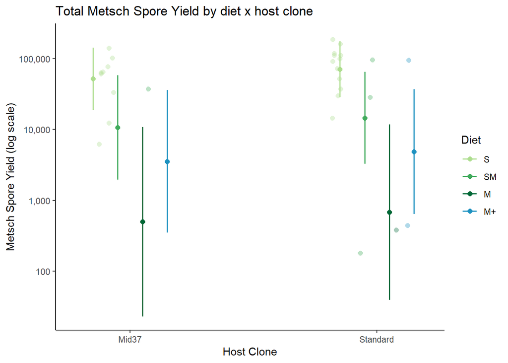

```r
m_totspore_fig <- plot(metsch_totspores, dodge = 0.4, add.data = T) +
  scale_color_manual(values = diet_colors) +
  ggtitle("Total Metsch Spore Yield by diet x host clone") +
  labs(x = "Host Clone", y = "Metsch Spore Yield (log scale)") +
  scale_y_log10(labels = scales::comma) +
  theme_classic()
m_totspore_fig
```

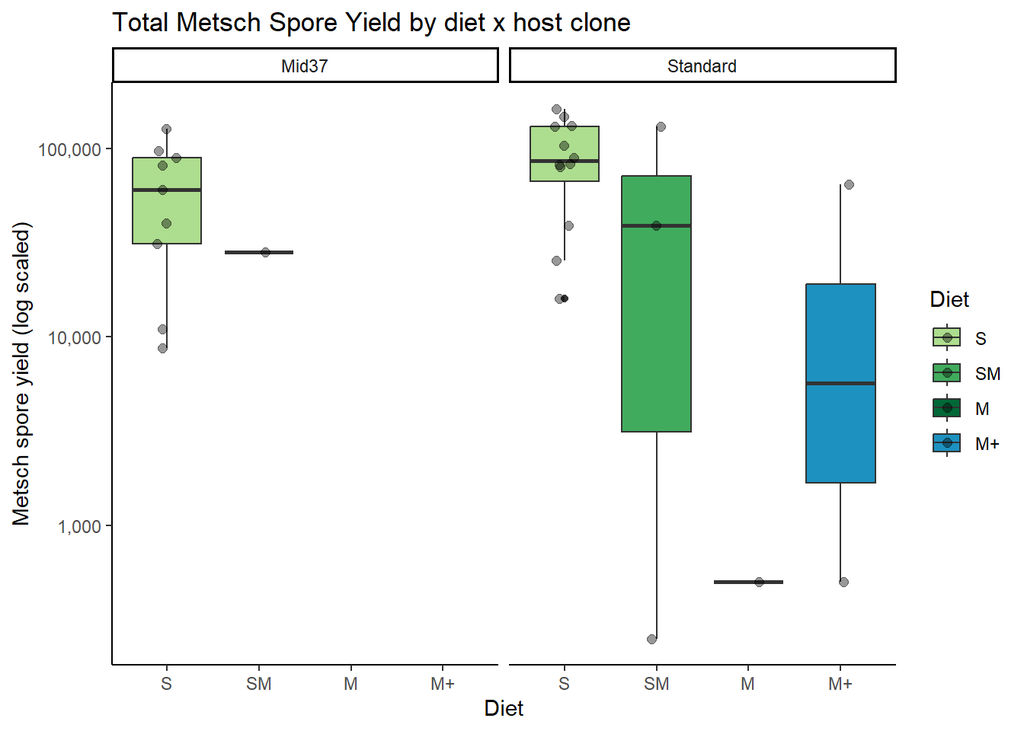

```r
m_totspore_fig2 <- ggplot(m_data_spores, aes(x = Diet, y = total_spores)) +
  geom_boxplot(aes(fill=Diet),position=position_dodge(width=0.7)) +
  geom_point(aes(color=Diet), size=2, position=position_jitterdodge(dodge.width=0.7, jitter.width = 0.7), alpha = 0.4) +
  facet_wrap(~Clone) +
  scale_fill_discrete(limits = c("S", "SM", "M", "M+")) +
  scale_fill_manual(values = diet_colors) +
  scale_color_manual(values = c(rep("black", 4))) +
  ylim(0,300000) +
  scale_y_log10(labels = scales::comma) +
  ggtitle("Total Metsch Spore Yield by diet x host clone") +
  labs(x = "Diet", y = "Metsch spore yield (log scaled)") +
  theme_classic()
m_totspore_fig2
```

**NOTE** There is something not working quite right for the predicted figure with points and error bars because the data points for mid37 are shifted, and there are predicted values for M and M+ in mid37s when there aren’t any data points for those treatments… USE THE BOXPLOT FIGURE!

### Comparison of Mature Metsch spore yield based on diet and host clone.

```r
mmaturesporemod <- lmer(log(mature_spores+1) ~ Diet + Clone + (1|Block), data = m_data_spores)
```

```
## boundary (singular) fit: see help('isSingular')
```

```r
summary(mmaturesporemod)
```

```
## Linear mixed model fit by REML. t-tests use Satterthwaite's method [
## lmerModLmerTest]
## Formula: log(mature_spores + 1) ~ Diet + Clone + (1 | Block)
##    Data: m_data_spores
##
## REML criterion at convergence: 97
##
## Scaled residuals:
##     Min      1Q  Median      3Q     Max
## -2.0394 -0.3563  0.1576  0.7048  1.2897
##
## Random effects:
##  Groups   Name        Variance Std.Dev.
##  Block    (Intercept) 0.000    0.000
##  Residual             2.942    1.715
## Number of obs: 28, groups:  Block, 3
##
## Fixed effects:
##               Estimate Std. Error      df t value Pr(>|t|)
## (Intercept)     9.7145     0.5505 23.0000  17.646 7.27e-15 ***
## DietSM         -1.2644     0.9441 23.0000  -1.339   0.1936
## DietM          -4.5578     1.7814 23.0000  -2.559   0.0176 *
## DietM+         -1.7398     1.3048 23.0000  -1.333   0.1955
## CloneStandard   0.3688     0.7065 23.0000   0.522   0.6067
## ---
## Signif. codes:  0 '***' 0.001 '**' 0.01 '*' 0.05 '.' 0.1 ' ' 1
##
## Correlation of Fixed Effects:
##             (Intr) DietSM DietM  DietM+
## DietSM      -0.171
## DietM       -0.018  0.106
## DietM+      -0.025  0.145  0.100
## CloneStndrd -0.733 -0.134 -0.170 -0.232
## optimizer (nloptwrap) convergence code: 0 (OK)
## boundary (singular) fit: see help('isSingular')
```

```r
Anova(mmaturesporemod)
```

```
## Analysis of Deviance Table (Type II Wald chisquare tests)
##
## Response: log(mature_spores + 1)
##        Chisq Df Pr(>Chisq)
## Diet  8.5959  3    0.03518 *
## Clone 0.2724  1    0.60171
## ---
## Signif. codes:  0 '***' 0.001 '**' 0.01 '*' 0.05 '.' 0.1 ' ' 1
```

```r
AIC(mmaturesporemod)
```

```
## [1] 110.9852
```

```r
mmaturesporemod_contrasts <- emmeans(mmaturesporemod, specs = pairwise ~ Diet | Clone, type = "response")
mmaturesporemod_contrasts
```

```
## $emmeans
## Clone = Mid37:
##  Diet response    SE    df lower.CL upper.CL
##  S       16554  9368 10.16  4703.30    58259
##  SM       4674  4804 22.50   555.59    39275
##  M         173   347 22.83     1.76    10899
##  M+       2905  4173 22.98   148.08    56659
##
## Clone = Standard:
##  Diet response    SE    df lower.CL upper.CL
##  S       23937 11637  7.34  7665.06    74748
##  SM       6760  6049 21.31  1052.43    43386
##  M         250   465 22.76     4.44    11587
##  M+       4201  5303 22.76   307.42    57261
##
## Degrees-of-freedom method: kenward-roger
## Confidence level used: 0.95
## Intervals are back-transformed from the log(mu + 1) scale
##
## $contrasts
## Clone = Mid37:
##  contrast    ratio     SE   df null t.ratio p.value
##  S / SM     3.5408   3.39 21.5    1   1.321  0.5599
##  S / M     95.3710 182.01 22.9    1   2.388  0.1078
##  S / (M+)   5.6962   7.73 22.4    1   1.283  0.5829
##  SM / M    26.9346  56.48 23.0    1   1.570  0.4143
##  SM / (M+)  1.6087   2.44 21.7    1   0.313  0.9891
##  M / (M+)   0.0597   0.14 22.8    1  -1.201  0.6325
##
## Clone = Standard:
##  contrast    ratio     SE   df null t.ratio p.value
##  S / SM     3.5408   3.39 21.5    1   1.321  0.5599
##  S / M     95.3710 182.01 22.9    1   2.388  0.1078
##  S / (M+)   5.6962   7.73 22.4    1   1.283  0.5829
##  SM / M    26.9346  56.48 23.0    1   1.570  0.4143
##  SM / (M+)  1.6087   2.44 21.7    1   0.313  0.9891
##  M / (M+)   0.0597   0.14 22.8    1  -1.201  0.6325
##
## Degrees-of-freedom method: kenward-roger
## P value adjustment: tukey method for comparing a family of 4 estimates
## Tests are performed on the log scale
```

```r
# Marginal effects from best model with Abundance on the x axis
metsch_maturespores <- ggpredict(mmaturesporemod, c("Clone", "Diet"))
```

```
## Could not compute variance-covariance matrix of predictions. No confidence intervals are returned.
```

```
## Model has log-transformed response. Back-transforming predictions to
##   original response scale. Standard errors are still on the log-scale.
```

```r
View(metsch_maturespores)

m_maturespore_fig <- plot(metsch_maturespores, dodge = 0.5, add.data = T, jitter = 0.05) +
  scale_color_manual(values = diet_colors) +
  ggtitle("Metsch Pasteuria Spore Yield by diet x host clone") +
  labs(x = "Host Clone", y = "Metsch Spore Yield (log scale)") +
  scale_y_log10(labels = scales::comma) +
  theme_classic()
```

```
## Raw data not available.
```

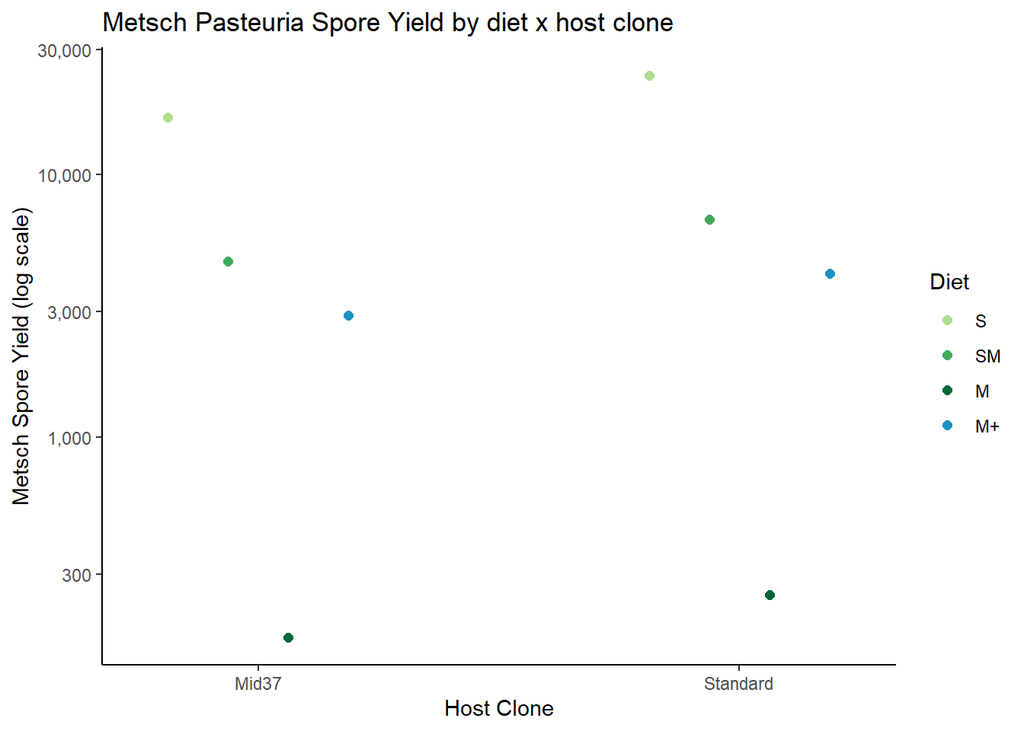

```r
m_maturespore_fig
```

```r
# figure for presentation
m_maturespore_fig3 <- plot(metsch_maturespores, dodge = 0.5, add.data = T, show.title = F) +
  scale_color_manual(values = diet_colors) +
  #ggtitle("Mature Pasteuria Spore Yield by diet x host clone") +
  labs(x = "Host Clone", y = "Mature Fungus Spore Yield (log scale)") +
  scale_y_log10(labels = scales::comma) +
  theme_classic() +
  theme(axis.text = element_text(size=9, color = "black"), axis.title.y = element_text(size=11, color="black"),
        axis.title.x = element_text(size=9, color="black"))
```

```
## Raw data not available.
```

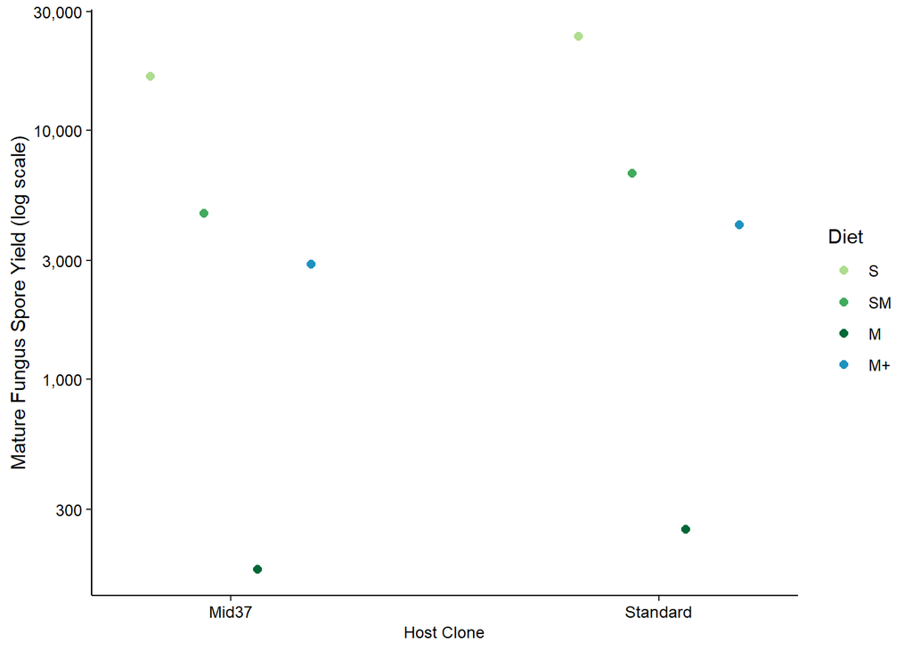

```r
m_maturespore_fig3
```

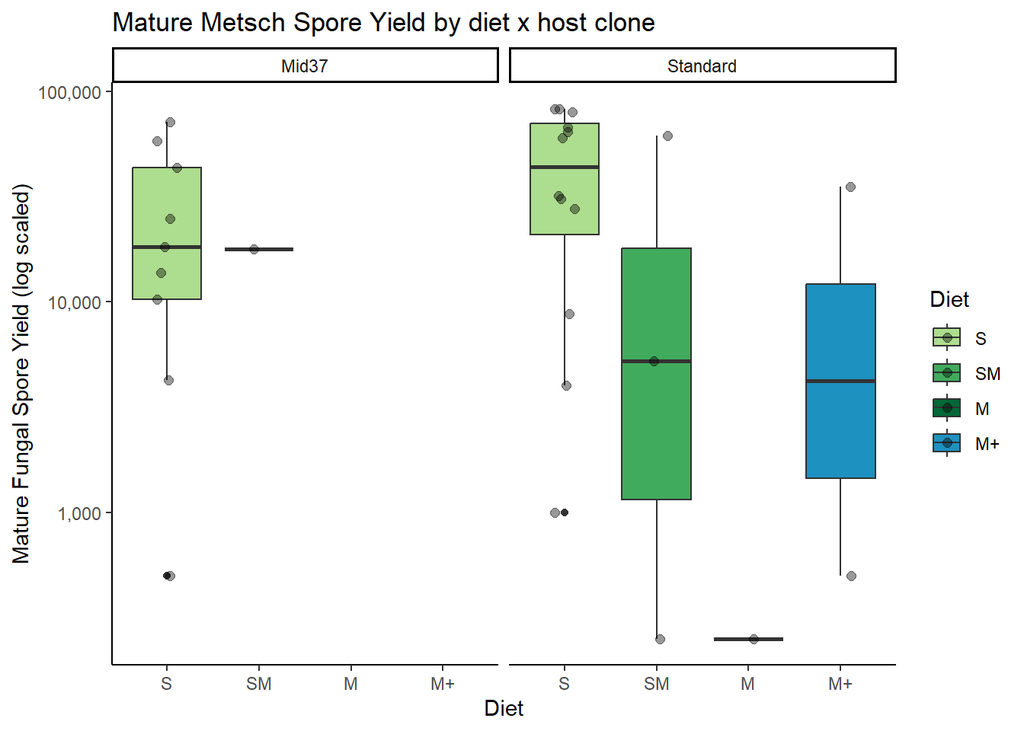

```r
ggsave("figures/MetschMatureSpores_DietxClone.tiff", plot = m_maturespore_fig3, dpi = 600, width = 4, height = 3, units = "in", compression="lzw")



m_maturespore_fig2 <- ggplot(m_data_spores, aes(x = Diet, y = mature_spores+1)) +
  geom_boxplot(aes(fill=Diet),position=position_dodge(width=0.7)) +
  geom_point(aes(color=Diet), size=2, position=position_jitterdodge(dodge.width=0.7, jitter.width = 0.7), alpha = 0.4) +
  facet_wrap(~Clone) +
  scale_fill_discrete(limits = c("S", "SM", "M", "M+")) +
  scale_fill_manual(values = diet_colors) +
  scale_color_manual(values = c(rep("black", 4))) +
  ylim(0,300000) +
  scale_y_log10(labels = scales::comma) +
  ggtitle("Mature Metsch Spore Yield by diet x host clone") +
  labs(x = "Diet", y = "Mature Fungal Spore Yield (log scaled)") +
  theme_classic()
m_maturespore_fig2
```

```r
ggsave("figures/MetschMatureSpores_DietxClone2.tiff", plot = m_maturespore_fig2, dpi = 600, width = 4, height = 3, units = "in", compression="lzw")
```

### Comparison of Immature Metsch spore yield based on diet and host clone.

```r
mimmaturesporemod <- lmer(log(immature_spores+1) ~ Diet + Clone + (1|Block), data = m_data_spores)
```

```
## boundary (singular) fit: see help('isSingular')
```

```r
summary(mimmaturesporemod)
```

```
## Linear mixed model fit by REML. t-tests use Satterthwaite's method [
## lmerModLmerTest]
## Formula: log(immature_spores + 1) ~ Diet + Clone + (1 | Block)
##    Data: m_data_spores
##
## REML criterion at convergence: 119.1
##
## Scaled residuals:
##      Min       1Q   Median       3Q      Max
## -2.82501 -0.07948  0.17914  0.39749  1.49506
##
## Random effects:
##  Groups   Name        Variance Std.Dev.
##  Block    (Intercept) 0.000    0.000
##  Residual             7.695    2.774
## Number of obs: 28, groups:  Block, 3
##
## Fixed effects:
##               Estimate Std. Error      df t value Pr(>|t|)
## (Intercept)     7.8363     0.8904 23.0000   8.801 8.03e-09 ***
## DietSM         -1.4075     1.5270 23.0000  -0.922   0.3662
## DietM          -2.9248     2.8811 23.0000  -1.015   0.3206
## DietM+         -4.3031     2.1103 23.0000  -2.039   0.0531 .
## CloneStandard   0.6139     1.1427 23.0000   0.537   0.5962
## ---
## Signif. codes:  0 '***' 0.001 '**' 0.01 '*' 0.05 '.' 0.1 ' ' 1
##
## Correlation of Fixed Effects:
##             (Intr) DietSM DietM  DietM+
## DietSM      -0.171
## DietM       -0.018  0.106
## DietM+      -0.025  0.145  0.100
## CloneStndrd -0.733 -0.134 -0.170 -0.232
## optimizer (nloptwrap) convergence code: 0 (OK)
## boundary (singular) fit: see help('isSingular')
```

```r
Anova(mimmaturesporemod)
```

```
## Analysis of Deviance Table (Type II Wald chisquare tests)
##
## Response: log(immature_spores + 1)
##        Chisq Df Pr(>Chisq)
## Diet  5.1369  3     0.1620
## Clone 0.2887  1     0.5911
```

```r
AIC(mimmaturesporemod)
```

```
## [1] 133.1007
```

```r
mimmaturesporemod_contrasts <- emmeans(mimmaturesporemod, specs = pairwise ~ Diet | Clone, type = "response")
mimmaturesporemod_contrasts
```

```
## $emmeans
## Clone = Mid37:
##  Diet response     SE    df lower.CL upper.CL
##  S      2529.9 2316.3 10.16 329.7569    19365
##  SM      618.5 1029.5 22.50  18.8217    19359
##  M       134.8  439.5 22.83  -0.8320   109864
##  M+       33.2   79.5 22.98  -0.7193     4174
##
## Clone = Standard:
##  Diet response     SE    df lower.CL upper.CL
##  S      4675.3 3676.7  7.34 740.4933    29490
##  SM     1143.6 1656.3 21.31  55.6057    23143
##  M       250.0  751.6 22.76  -0.4896   123427
##  M+       62.3  129.1 22.76  -0.0743     4321
##
## Degrees-of-freedom method: kenward-roger
## Confidence level used: 0.95
## Intervals are back-transformed from the log(mu + 1) scale
##
## $contrasts
## Clone = Mid37:
##  contrast  ratio     SE   df null t.ratio p.value
##  S / SM     4.09   6.32 21.5    1   0.909  0.8000
##  S / M     18.63  57.50 22.9    1   0.948  0.7798
##  S / (M+)  73.93 162.18 22.4    1   1.962  0.2321
##  SM / M     4.56  15.47 23.0    1   0.447  0.9695
##  SM / (M+) 18.10  44.46 21.7    1   1.178  0.6464
##  M / (M+)   3.97  15.06 22.8    1   0.363  0.9832
##
## Clone = Standard:
##  contrast  ratio     SE   df null t.ratio p.value
##  S / SM     4.09   6.32 21.5    1   0.909  0.8000
##  S / M     18.63  57.50 22.9    1   0.948  0.7798
##  S / (M+)  73.93 162.18 22.4    1   1.962  0.2321
##  SM / M     4.56  15.47 23.0    1   0.447  0.9695
##  SM / (M+) 18.10  44.46 21.7    1   1.178  0.6464
##  M / (M+)   3.97  15.06 22.8    1   0.363  0.9832
##
## Degrees-of-freedom method: kenward-roger
## P value adjustment: tukey method for comparing a family of 4 estimates
## Tests are performed on the log scale
```

```r
# Marginal effects from best model with Abundance on the x axis
metsch_immaturespores <- ggpredict(mimmaturesporemod, c("Clone", "Diet"))
```

```
## Could not compute variance-covariance matrix of predictions. No confidence intervals are returned.
```

```
## Model has log-transformed response. Back-transforming predictions to
##   original response scale. Standard errors are still on the log-scale.
```

```r
m_immaturespore_fig <- plot(metsch_immaturespores, dodge = 0.4, add.data = T) +
  scale_color_manual(values = diet_colors) +
  ggtitle("Immature Metsch Spore Yield by diet x host clone") +
  labs(x = "Host Clone", y = "Immature Metsch Spore Yield (log scale)") +
  scale_y_log10(labels = scales::comma) +
  theme_classic()
```

```
## Raw data not available.
```

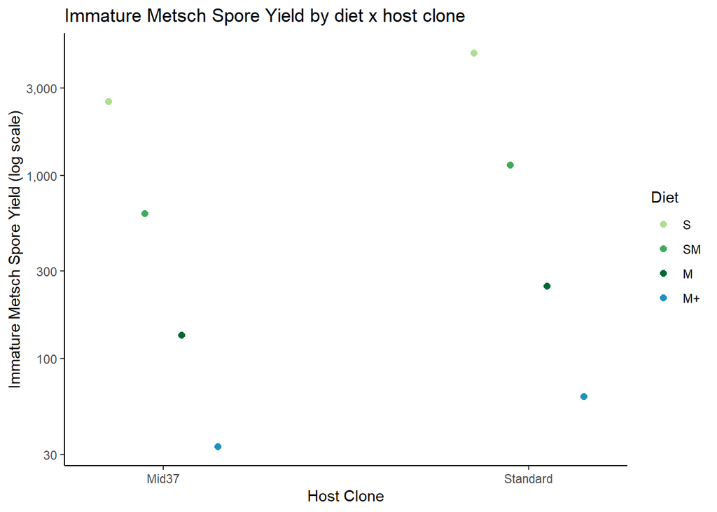

```r
m_immaturespore_fig
```

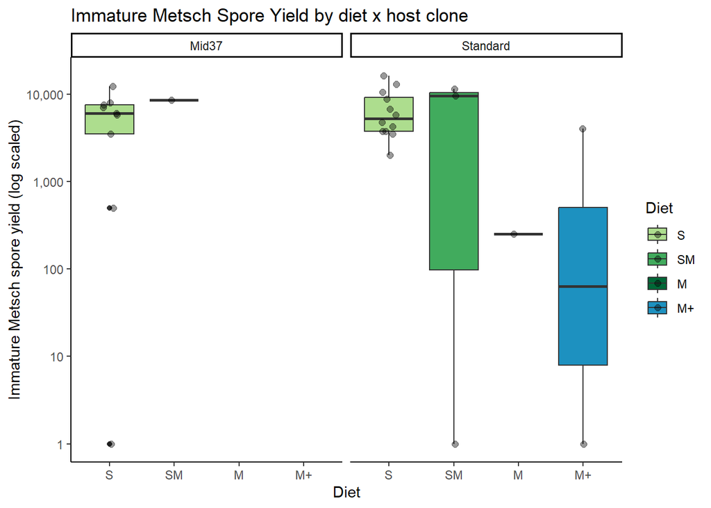

```r
m_immaturespore_fig2 <- ggplot(m_data_spores, aes(x = Diet, y = immature_spores+1)) +
  geom_boxplot(aes(fill=Diet),position=position_dodge(width=0.7)) +
  geom_point(aes(color=Diet), size=2, position=position_jitterdodge(dodge.width=0.7, jitter.width = 0.7), alpha = 0.4) +
  facet_wrap(~Clone) +
  scale_fill_discrete(limits = c("S", "SM", "M", "M+")) +
  scale_fill_manual(values = diet_colors) +
  scale_color_manual(values = c(rep("black", 4))) +
  ylim(0,300000) +
  scale_y_log10(labels = scales::comma) +
  ggtitle("Immature Metsch Spore Yield by diet x host clone") +
  labs(x = "Diet", y = "Immature Metsch spore yield (log scaled)") +
  theme_classic()
m_immaturespore_fig2
```

Overall there are many fewer immature spores compared to mature spores in the infected animals.

### Comparison of Budding Metsch spore yield based on diet and host clone.

```r
mbudsporemod <- lmer(log(bud_spores+1) ~ Diet + Clone + (1|Block), data = m_data_spores)
summary(mbudsporemod)
```

```
## Linear mixed model fit by REML. t-tests use Satterthwaite's method [
## lmerModLmerTest]
## Formula: log(bud_spores + 1) ~ Diet + Clone + (1 | Block)
##    Data: m_data_spores
##
## REML criterion at convergence: 112.6
##
## Scaled residuals:
##      Min       1Q   Median       3Q      Max
## -2.85405 -0.27739  0.05871  0.32252  2.00962
##
## Random effects:
##  Groups   Name        Variance Std.Dev.
##  Block    (Intercept) 0.7859   0.8865
##  Residual             5.3995   2.3237
## Number of obs: 28, groups:  Block, 3
##
## Fixed effects:
##               Estimate Std. Error      df t value Pr(>|t|)
## (Intercept)    10.2072     0.9102  4.9884  11.214 9.99e-05 ***
## DietSM         -3.1638     1.2829 20.9095  -2.466 0.022393 *
## DietM          -9.7957     2.4581 21.9168  -3.985 0.000629 ***
## DietM+         -5.6364     1.7880 21.5314  -3.152 0.004705 **
## CloneStandard   0.1945     0.9587 20.8304   0.203 0.841236
## ---
## Signif. codes:  0 '***' 0.001 '**' 0.01 '*' 0.05 '.' 0.1 ' ' 1
##
## Correlation of Fixed Effects:
##             (Intr) DietSM DietM  DietM+
## DietSM      -0.141
## DietM       -0.003  0.091
## DietM+      -0.033  0.151  0.069
## CloneStndrd -0.606 -0.131 -0.174 -0.222
```

```r
Anova(mbudsporemod)
```

```
## Analysis of Deviance Table (Type II Wald chisquare tests)
##
## Response: log(bud_spores + 1)
##         Chisq Df Pr(>Chisq)
## Diet  27.1185  3   5.56e-06 ***
## Clone  0.0411  1     0.8393
## ---
## Signif. codes:  0 '***' 0.001 '**' 0.01 '*' 0.05 '.' 0.1 ' ' 1
```

```r
AIC(mbudsporemod)
```

```
## [1] 126.5689
```

```r
mbudsporemod_contrasts <- emmeans(mbudsporemod, specs = pairwise ~ Diet | Clone, type = "response")
mbudsporemod_contrasts
```

```
## $emmeans
## Clone = Mid37:
##  Diet response       SE    df lower.CL upper.CL
##  S    27097.37 24933.49  5.63 2749.844   266943
##  SM    1144.32  1688.73 18.45   50.991    25230
##  M        0.51     4.09 22.93   -0.994      411
##  M+      95.63   193.04 22.49    0.542     6055
##
## Clone = Standard:
##  Diet response       SE    df lower.CL upper.CL
##  S    32914.05 27427.95  4.13 3351.461   323165
##  SM    1390.16  1816.57 15.28   85.412    22395
##  M        0.83     4.61 22.81   -0.990      331
##  M+     116.37   207.45 21.05    1.975     4630
##
## Degrees-of-freedom method: kenward-roger
## Confidence level used: 0.95
## Intervals are back-transformed from the log(mu + 1) scale
##
## $contrasts
## Clone = Mid37:
##  contrast     ratio       SE   df null t.ratio p.value
##  S / SM    2.37e+01    30.51 21.2    1   2.454  0.0971
##  S / M     1.80e+04 45507.31 22.1    1   3.865  0.0043
##  S / (M+)  2.80e+02   511.26 21.7    1   3.092  0.0256
##  SM / M    7.59e+02  2100.12 22.2    1   2.397  0.1069
##  SM / (M+) 1.19e+01    24.36 21.4    1   1.203  0.6315
##  M / (M+)  1.60e-02     0.05 22.6    1  -1.345  0.5450
##
## Clone = Standard:
##  contrast     ratio       SE   df null t.ratio p.value
##  S / SM    2.37e+01    30.51 21.2    1   2.454  0.0971
##  S / M     1.80e+04 45507.31 22.1    1   3.865  0.0043
##  S / (M+)  2.80e+02   511.26 21.7    1   3.092  0.0256
##  SM / M    7.59e+02  2100.12 22.2    1   2.397  0.1069
##  SM / (M+) 1.19e+01    24.36 21.4    1   1.203  0.6315
##  M / (M+)  1.60e-02     0.05 22.6    1  -1.345  0.5450
##
## Degrees-of-freedom method: kenward-roger
## P value adjustment: tukey method for comparing a family of 4 estimates
## Tests are performed on the log scale
```

```r
# Marginal effects from best model with Abundance on the x axis
metsch_budspores <- ggpredict(mbudsporemod, c("Clone", "Diet"))
```

```
## Could not compute variance-covariance matrix of predictions. No confidence intervals are returned.
```

```
## Model has log-transformed response. Back-transforming predictions to
##   original response scale. Standard errors are still on the log-scale.
```

```r
m_budspore_fig <- plot(metsch_budspores, dodge = 0.4, add.data = T) +
  scale_color_manual(values = diet_colors) +
  ggtitle("Budding Metsch Spore Yield by diet x host clone") +
  labs(x = "Host Clone", y = "Budding Metsch Spore Yield (log scale)") +
  scale_y_log10(labels = scales::comma) +
  theme_classic()
```

```
## Raw data not available.
```

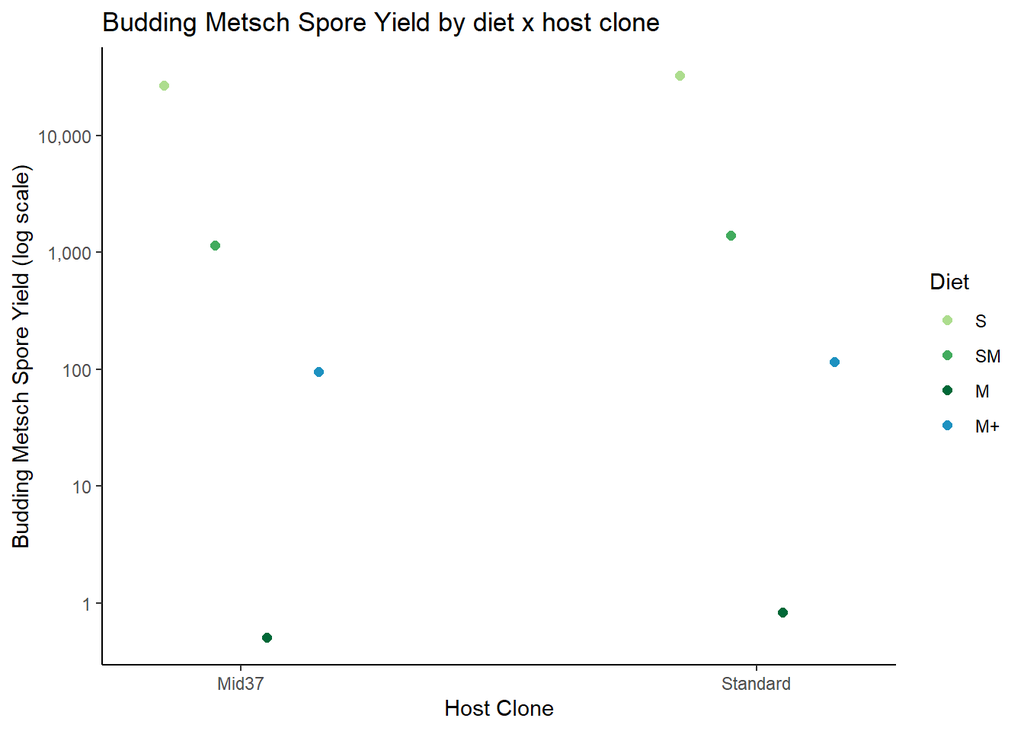

```r
m_budspore_fig
```

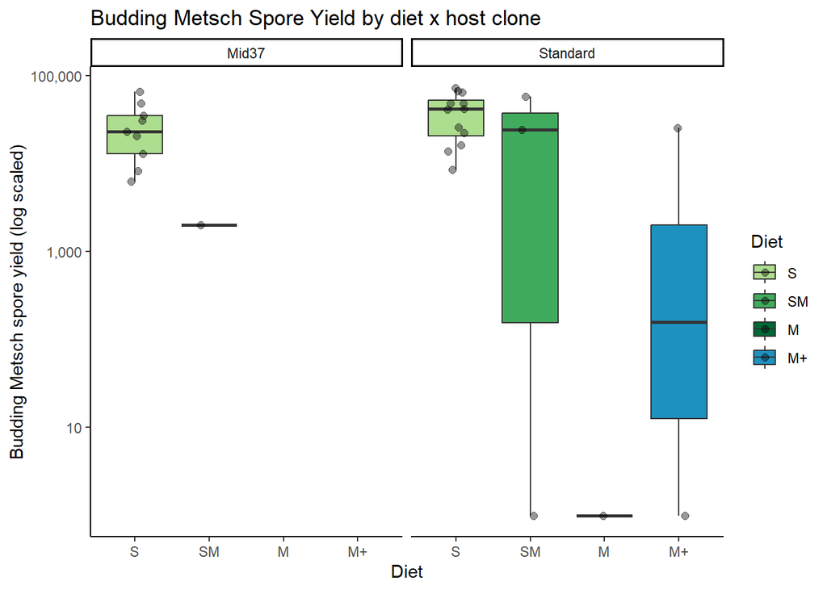

```r
m_budspore_fig2 <- ggplot(m_data_spores, aes(x = Diet, y = bud_spores+1)) +
  geom_boxplot(aes(fill=Diet),position=position_dodge(width=0.7)) +
  geom_point(aes(color=Diet), size=2, position=position_jitterdodge(dodge.width=0.7, jitter.width = 0.7), alpha = 0.4) +
  facet_wrap(~Clone) +
  scale_fill_discrete(limits = c("S", "SM", "M", "M+")) +
  scale_fill_manual(values = diet_colors) +
  scale_color_manual(values = c(rep("black", 4))) +
  ylim(0,300000) +
  scale_y_log10(labels = scales::comma) +
  ggtitle("Budding Metsch Spore Yield by diet x host clone") +
  labs(x = "Diet", y = "Budding Metsch spore yield (log scaled)") +
  theme_classic()
m_budspore_fig2
```

## Gut spore data for Metsch

The day after Metsch exposure, we looked at the number of Metsch spores that were embedded in or punctured through the gut wall of the daphnia, as well as the number of Metsch spores that were entirely in the haemoceol (body cavity) of the daphnia. We counted the number of hemocytes that were attached to either punctured or haemoceol spores that had passed partially or completely through the gut wall.

### Total number of spores in the gut

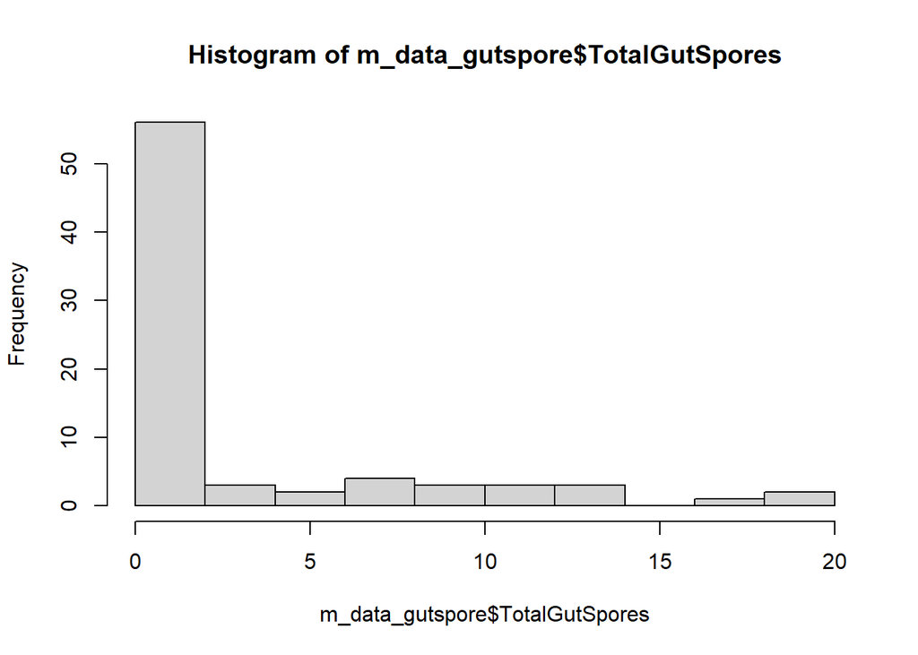

```r
m_data_gutspore <- m_data %>% filter(Block == 5 & Infection != "Uninfected")
# only include animals in block 5 that were checked for gut spores and remove 3 animals that did not get exposed to parasites (STD SM, M, and M+ rep 20 for all, b/c ran out of spores for exposure)
hist(m_data_gutspore$TotalGutSpores)
```

```r
mgutsporemod <- glm(TotalGutSpores ~ Diet * Clone, family = poisson, data = m_data_gutspore)
# Note: left off the block random effect because all these animals were in the same block
summary(mgutsporemod)
```

```
##
## Call:
## glm(formula = TotalGutSpores ~ Diet * Clone, family = poisson,
##     data = m_data_gutspore)
##
## Deviance Residuals:
##     Min       1Q   Median       3Q      Max
## -2.3283  -0.7746  -0.6325   0.2551   2.0875
##
## Coefficients:
##                       Estimate Std. Error z value Pr(>|z|)
## (Intercept)             1.9879     0.1170  16.984  < 2e-16 ***
## DietSM                -20.2905  1808.0424  -0.011    0.991
## DietM                  -3.5973     0.7167  -5.019 5.19e-07 ***
## DietM+                 -3.1918     0.5891  -5.418 6.02e-08 ***
## CloneStandard           0.6295     0.1449   4.344 1.40e-05 ***
## DietSM:CloneStandard   17.4217  1808.0425   0.010    0.992
## DietM:CloneStandard     0.5745     0.8293   0.693    0.488
## DietM+:CloneStandard   -0.9296     0.9243  -1.006    0.315
## ---
## Signif. codes:  0 '***' 0.001 '**' 0.01 '*' 0.05 '.' 0.1 ' ' 1
##
## (Dispersion parameter for poisson family taken to be 1)
##
##     Null deviance: 548.55  on 76  degrees of freedom
## Residual deviance:  72.58  on 69  degrees of freedom
## AIC: 201.42
##
## Number of Fisher Scoring iterations: 16
```

```r
Anova(mgutsporemod)
```

```
## Analysis of Deviance Table (Type II tests)
##
## Response: TotalGutSpores
##            LR Chisq Df Pr(>Chisq)
## Diet         437.61  3  < 2.2e-16 ***
## Clone         24.93  1   5.96e-07 ***
## Diet:Clone     8.00  3    0.04599 *
## ---
## Signif. codes:  0 '***' 0.001 '**' 0.01 '*' 0.05 '.' 0.1 ' ' 1
```

```r
overdisp_fun(mgutsporemod)
```

```
##      chisq      ratio        rdf          p
## 73.6802749  1.0678301 69.0000000  0.3277191
```

```r
AIC(mgutsporemod)
```

```
## [1] 201.4181
```

```r
mgutsporemod2 <- glm(TotalGutSpores ~ Diet * Clone * length.um, family = poisson, data = m_data_gutspore)
# Note: left off the block random effect because all these animals were in the same block
summary(mgutsporemod2)
```

```
##
## Call:
## glm(formula = TotalGutSpores ~ Diet * Clone * length.um, family = poisson,
##     data = m_data_gutspore)
##
## Deviance Residuals:
##     Min       1Q   Median       3Q      Max
## -2.1489  -0.6992  -0.4583   0.2398   1.9101
##
## Coefficients:
##                                  Estimate Std. Error z value Pr(>|z|)
## (Intercept)                     7.786e-01  1.594e+00   0.488   0.6253
## DietSM                         -1.908e+01  4.406e+04   0.000   0.9997
## DietM                          -8.096e+00  1.869e+01  -0.433   0.6649
## DietM+                          8.149e+00  6.495e+00   1.255   0.2096
## CloneStandard                   3.814e+00  3.055e+00   1.248   0.2119
## length.um                       1.115e-03  1.462e-03   0.763   0.4454
## DietSM:CloneStandard            1.419e+01  4.406e+04   0.000   0.9997
## DietM:CloneStandard            -1.318e+01  2.205e+01  -0.598   0.5499
## DietM+:CloneStandard           -2.185e+01  2.311e+01  -0.946   0.3442
## DietSM:length.um               -1.115e-03  4.451e+01   0.000   1.0000
## DietM:length.um                 5.044e-03  2.004e-02   0.252   0.8013
## DietM+:length.um               -1.246e-02  7.471e-03  -1.667   0.0954 .
## CloneStandard:length.um        -2.793e-03  2.654e-03  -1.052   0.2926
## DietSM:CloneStandard:length.um  2.836e-03  4.451e+01   0.000   0.9999
## DietM:CloneStandard:length.um   1.214e-02  2.282e-02   0.532   0.5949
## DietM+:CloneStandard:length.um  2.131e-02  2.208e-02   0.965   0.3346
## ---
## Signif. codes:  0 '***' 0.001 '**' 0.01 '*' 0.05 '.' 0.1 ' ' 1
##
## (Dispersion parameter for poisson family taken to be 1)
##
##     Null deviance: 548.548  on 76  degrees of freedom
## Residual deviance:  65.885  on 61  degrees of freedom
## AIC: 210.72
##
## Number of Fisher Scoring iterations: 16
```

```r
Anova(mgutsporemod2)
```

```
## Analysis of Deviance Table (Type II tests)
##
## Response: TotalGutSpores
##                      LR Chisq Df Pr(>Chisq)
## Diet                  207.857  3  < 2.2e-16 ***
## Clone                  13.000  1  0.0003115 ***
## length.um               0.051  1  0.8209493
## Diet:Clone              4.443  3  0.2174077
## Diet:length.um          5.167  3  0.1599486
## Clone:length.um         0.815  1  0.3667600
## Diet:Clone:length.um    1.231  3  0.7455444
## ---
## Signif. codes:  0 '***' 0.001 '**' 0.01 '*' 0.05 '.' 0.1 ' ' 1
```

```r
overdisp_fun(mgutsporemod2)
```

```
##      chisq      ratio        rdf          p
## 68.0105267  1.1149267 61.0000000  0.2508726
```

```r
AIC(mgutsporemod2)
```

```
## [1] 210.7229
```

```r
mgutsporemod_contrasts <- emmeans(mgutsporemod, specs = pairwise ~ Diet | Clone, type = "response")
mgutsporemod_contrasts
```

```
## $emmeans
## Clone = Mid37:
##  Diet   rate       SE  df asymp.LCL asymp.UCL
##  S     7.300 8.54e-01 Inf    5.8036         9
##  SM    0.000 2.03e-05 Inf    0.0000       Inf
##  M     0.200 1.41e-01 Inf    0.0500         1
##  M+    0.300 1.73e-01 Inf    0.0968         1
##
## Clone = Standard:
##  Diet   rate       SE  df asymp.LCL asymp.UCL
##  S    13.700 1.17e+00 Inf   11.5877        16
##  SM    0.778 2.94e-01 Inf    0.3708         2
##  M     0.667 2.72e-01 Inf    0.2995         1
##  M+    0.222 1.57e-01 Inf    0.0556         1
##
## Confidence level used: 0.95
## Intervals are back-transformed from the log scale
##
## $contrasts
## Clone = Mid37:
##  contrast     ratio       SE  df null z.ratio p.value
##  S / SM    6.49e+08 1.17e+12 Inf    1   0.011  1.0000
##  S / M     3.70e+01 2.60e+01 Inf    1   5.019  <.0001
##  S / (M+)  2.40e+01 1.40e+01 Inf    1   5.418  <.0001
##  SM / M    0.00e+00 0.00e+00 Inf    1  -0.009  1.0000
##  SM / (M+) 0.00e+00 0.00e+00 Inf    1  -0.009  1.0000
##  M / (M+)  1.00e+00 1.00e+00 Inf    1  -0.444  0.9708
##
## Clone = Standard:
##  contrast     ratio       SE  df null z.ratio p.value
##  S / SM    1.80e+01 7.00e+00 Inf    1   7.403  <.0001
##  S / M     2.10e+01 9.00e+00 Inf    1   7.247  <.0001
##  S / (M+)  6.20e+01 4.40e+01 Inf    1   5.787  <.0001
##  SM / M    1.00e+00 1.00e+00 Inf    1   0.277  0.9926
##  SM / (M+) 4.00e+00 3.00e+00 Inf    1   1.562  0.4003
##  M / (M+)  3.00e+00 2.00e+00 Inf    1   1.346  0.5338
##
## P value adjustment: tukey method for comparing a family of 4 estimates
## Tests are performed on the log scale
```

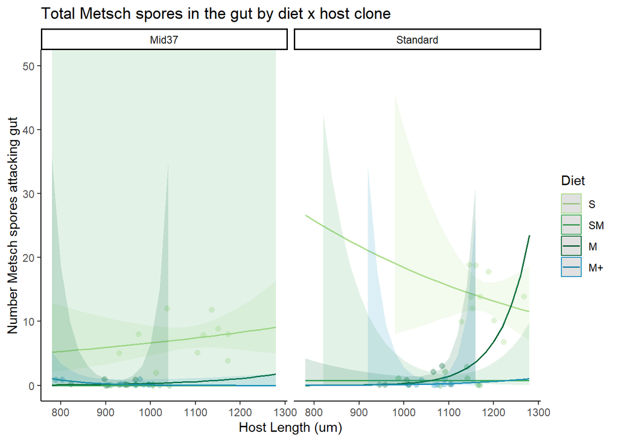

```r
# Marginal effects from best model with Abundance on the x axis
metsch_totgutspores <- ggpredict(mgutsporemod2, c("length.um", "Diet", "Clone"))

# figure with bodysize
m_totgutspores_fig <- plot(metsch_totgutspores, dodge = 0.4, add.data = T) +
  scale_color_manual(values = diet_colors) +
  scale_fill_manual(values = diet_colors) +
  ggtitle("Total Metsch spores in the gut by diet x host clone") +
  labs(x = "Host Length (um)", y = "Number Metsch spores attacking gut") +
  ylim(0,50) +
  theme_classic()
m_totgutspores_fig
```

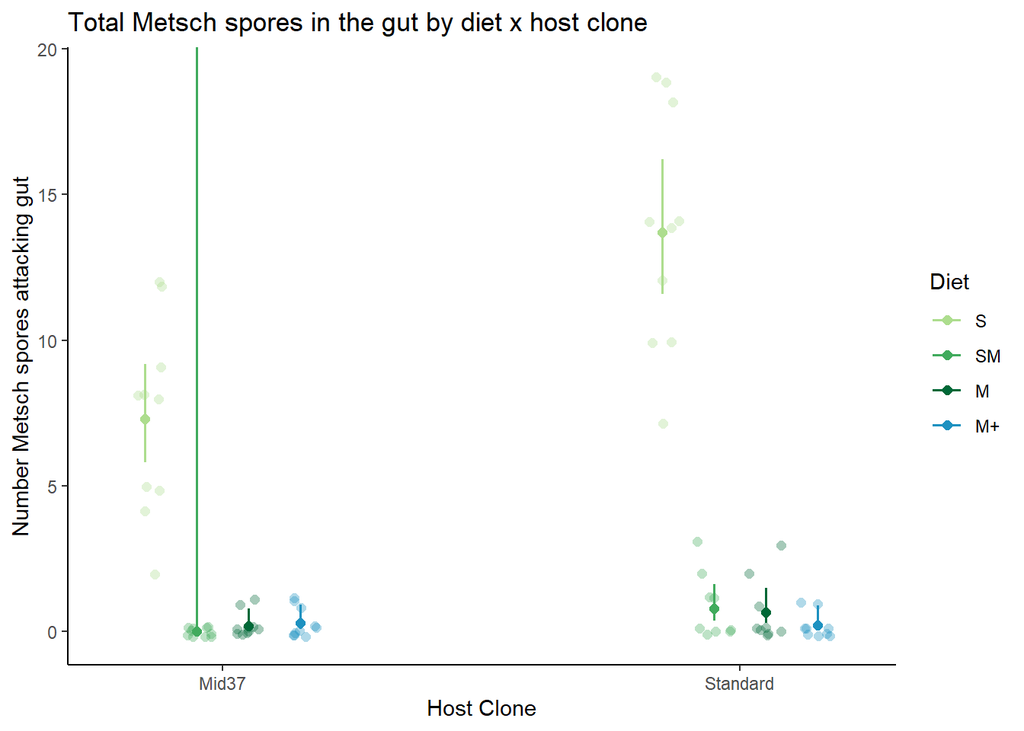

```r
# Marginal effects from best model with Abundance on the x axis
metsch_totgutspores1 <- ggpredict(mgutsporemod, c("Clone", "Diet"))

m_totgutspores_fig1 <- plot(metsch_totgutspores1, dodge = 0.4, add.data = T) +
  scale_color_manual(values = diet_colors) +
  ggtitle("Total Metsch spores in the gut by diet x host clone") +
  labs(x = "Host Clone", y = "Number Metsch spores attacking gut") +
  theme_classic()
m_totgutspores_fig1
```

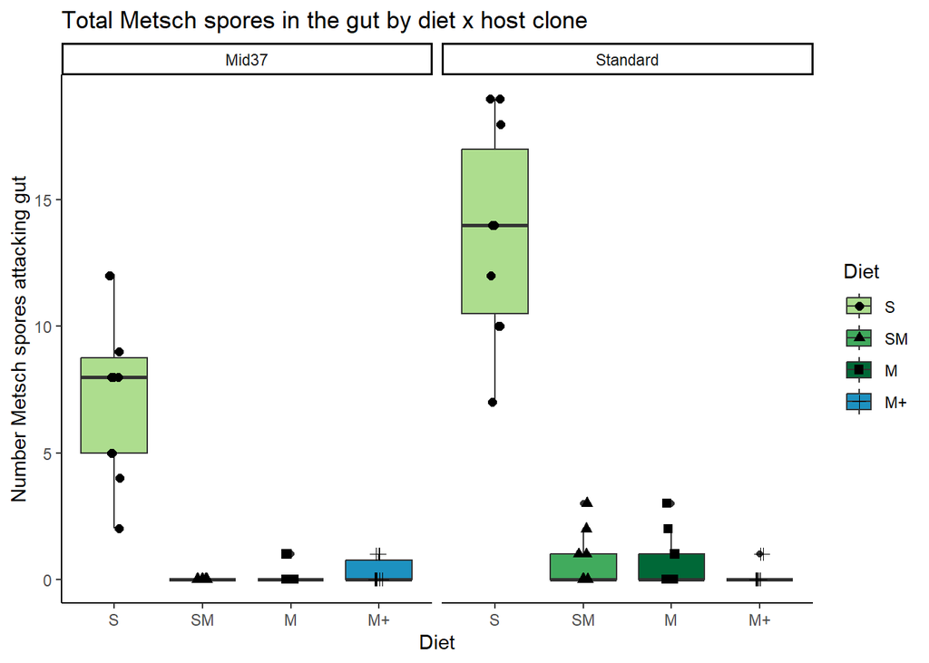

```r
m_totgutspores_fig2 <- ggplot(m_data_gutspore, aes(x = Diet, y = TotalGutSpores)) +
  geom_boxplot(aes(fill=Diet),position=position_dodge()) +
  geom_point(aes(shape=Diet), size=2, position=position_jitterdodge()) +
  facet_wrap(~Clone) +
  scale_fill_discrete(limits = c("S", "SM", "M", "M+")) +
  scale_shape_discrete(limits = c("S", "SM", "M", "M+")) +
  scale_fill_manual(values = diet_colors) +
  ggtitle("Total Metsch spores in the gut by diet x host clone") +
  labs(x = "Diet", y = "Number Metsch spores attacking gut") +
  theme_classic()
m_totgutspores_fig2
```

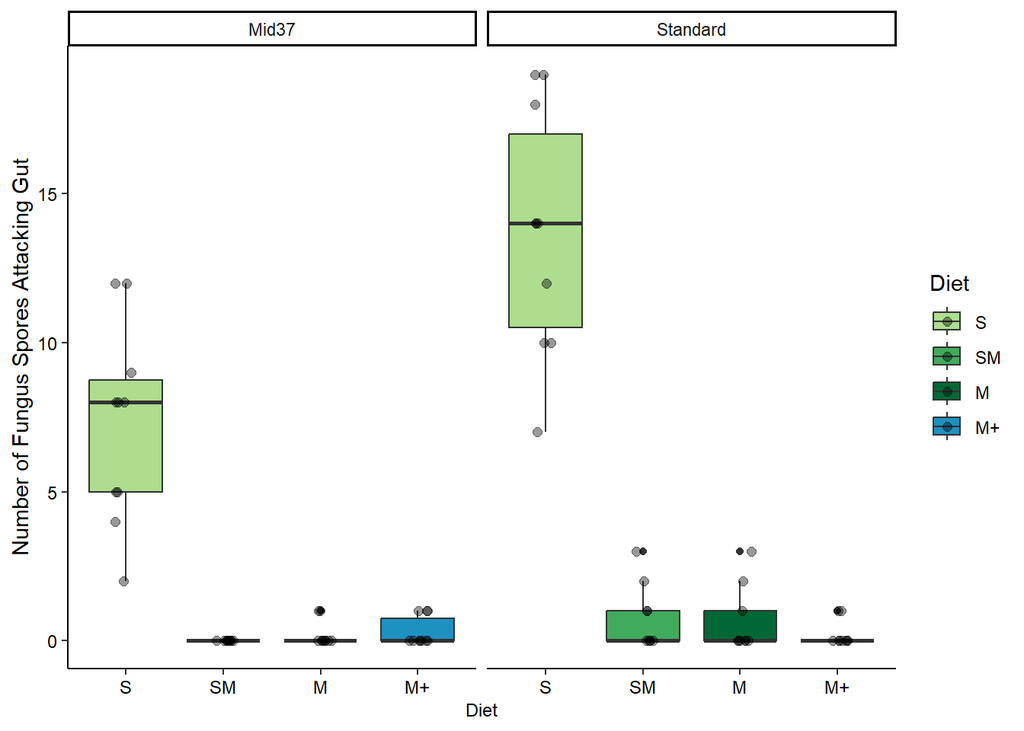

```r
# figure for presentation
m_totgutspores_fig3 <- ggplot(m_data_gutspore, aes(x = Diet, y = TotalGutSpores)) +
  geom_boxplot(aes(fill=Diet),position=position_dodge(width=0.7)) +
  geom_point(aes(color=Diet), size=2, position=position_jitterdodge(dodge.width=0.7, jitter.width = 0.7), alpha = 0.4) +
  facet_wrap(~Clone) +
  scale_fill_discrete(limits = c("S", "SM", "M", "M+")) +
  scale_fill_manual(values = diet_colors) +
  scale_color_manual(values = c(rep("black", 4))) +
  labs(x = "Diet", y = "Number of Fungus Spores Attacking Gut") +
  theme_classic() +
  theme(axis.text = element_text(size=9, color = "black"), axis.title.y = element_text(size=11, color="black"),
        axis.title.x = element_text(size=9, color="black"))
m_totgutspores_fig3
```

```r
ggsave("figures/MetschGutSpores_DietxClone.tiff", plot = m_totgutspores_fig3, dpi = 600, width = 5, height = 4, units = "in", compression="lzw")
```

The effect of diet treatment and host clone were significant. Bodysize was not a significant predictor of the number of attacking metsch spores in the gut, and the model that included bodysize made the interaction between Diet*Clone insignificant (it was sig in the model without bodyzie included and the AIC is lower by ~9 in that model). There were substantially more Metsch spores attacking the guts of animals fed the high-quality Scenedesmus diet, and Standards tended to have more spores in their guts than Mid37s. This fits with our understanding that Standards tend to be more susceptible to Metsch than Mid37s.

**Diets that included any Microcystis appear to really protect hosts from early exposure to attacking spores!**

I didn’t run the models or figures for the different degrees of spore penetration into the gut (i.e. embedded, punctured, and haemoceol spores), but the pattern above is largely the same for the embedded and punctured spores. There were relatively few haemoceol spores overall, and all of the ones that I saw were in the S treatments.

Tara Stewart Merrill looked at the proportion of attacking spores and a few other ways of calculating these spores counts, so we could potentially update these response variables to match what she previously did. (Note, I think that she included both embedded and punctured spores as “barrier spores” in her paper, so my “total gut spore” count is equivalent to her “Attacking spore” count)

### Hemocytes per punctured or haemoceol spore

We counted the number of hemocytes that were attached to metsch spores that had punctured or penetrated into the haemoceol of the daphnia. We then calculated the number of hemocytes per punctured or haemoceol spore by dividing the number of hemocytes counted by the total number of punctured and haemoceol spores (“TotalPunctSpores” column).

**Needed to filter data to remove animals where there were no punctured spores because then there would also not be any hemocytes counted, so there would to separation in the data.**

```r
m_data_hemocytes <- m_data_gutspore %>% filter(TotalGutSpores > 0)
dim(m_data_hemocytes)
```

```
## [1] 34 38
```

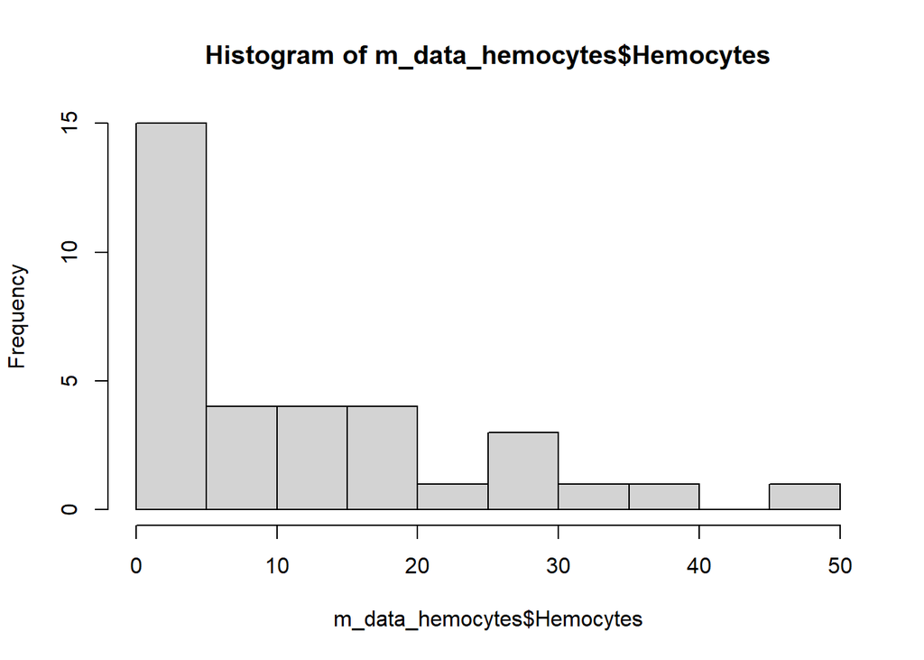

```r
m_data_hemocytes$Unique.code <- as.factor(m_data_hemocytes$Unique.code)

hist(m_data_hemocytes$Hemocytes)
```

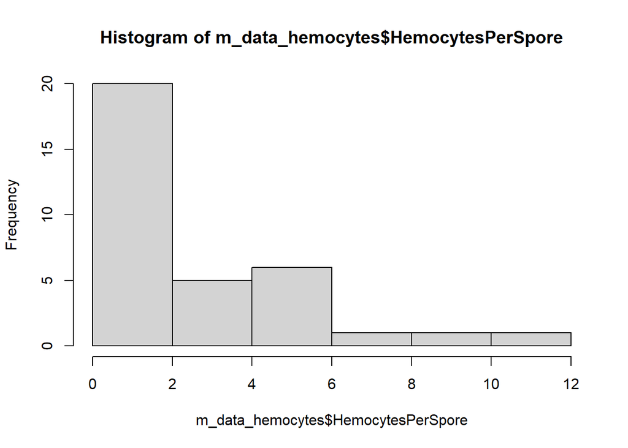

```r
hist(m_data_hemocytes$HemocytesPerSpore)
```

```r
# I'm not sure what is the best distribution to use for this data since it doesn't look normal but a poisson won't fit because the data are not integers...

# Number of hemocytes
mhemocytemod <- glmer(Hemocytes ~ Diet * Clone + TotalPunctSpores + (1|Unique.code), family = "poisson", data = m_data_hemocytes, control=glmerControl(optimizer="bobyqa", optCtrl=list(maxfun=2e5)))
```

```
## fixed-effect model matrix is rank deficient so dropping 1 column / coefficient
```

```r
summary(mhemocytemod)
```

```
## Generalized linear mixed model fit by maximum likelihood (Laplace
##   Approximation) [glmerMod]
##  Family: poisson  ( log )
## Formula: Hemocytes ~ Diet * Clone + TotalPunctSpores + (1 | Unique.code)
##    Data: m_data_hemocytes
## Control: glmerControl(optimizer = "bobyqa", optCtrl = list(maxfun = 2e+05))
##
##      AIC      BIC   logLik deviance df.resid
##    220.8    234.5   -101.4    202.8       25
##
## Scaled residuals:
##      Min       1Q   Median       3Q      Max
## -1.41253 -0.32615 -0.02718  0.28482  0.76799
##
## Random effects:
##  Groups      Name        Variance Std.Dev.
##  Unique.code (Intercept) 0.5089   0.7134
## Number of obs: 34, groups:  Unique.code, 34
##
## Fixed effects:
##                      Estimate Std. Error z value Pr(>|z|)
## (Intercept)           1.70618    0.38327   4.452 8.52e-06 ***
## DietSM               -1.35492    0.92511  -1.465  0.14303
## DietM                -2.81580    1.18038  -2.386  0.01706 *
## DietM+               -0.74396    0.61342  -1.213  0.22520
## CloneStandard        -0.76266    0.56601  -1.347  0.17784
## TotalPunctSpores      0.20096    0.07676   2.618  0.00884 **
## DietM:CloneStandard   2.63670    1.37086   1.923  0.05443 .
## DietM+:CloneStandard -0.16010    1.11933  -0.143  0.88627
## ---
## Signif. codes:  0 '***' 0.001 '**' 0.01 '*' 0.05 '.' 0.1 ' ' 1
##
## Correlation of Fixed Effects:
##             (Intr) DietSM DietM  DietM+ ClnStn TtlPnS DtM:CS
## DietSM      -0.500
## DietM       -0.259  0.112
## DietM+      -0.520  0.223  0.141
## CloneStndrd  0.280 -0.651 -0.034 -0.073
## TtlPnctSprs -0.742  0.684  0.163  0.330 -0.785
## DtM:ClnStnd -0.098  0.255 -0.788  0.023 -0.398  0.303
## DtM+:ClnStn -0.147  0.341  0.020 -0.355 -0.521  0.412  0.208
## fit warnings:
## fixed-effect model matrix is rank deficient so dropping 1 column / coefficient
```

```r
Anova(mhemocytemod)
```

```
## Analysis of Deviance Table (Type II Wald chisquare tests)
##
## Response: Hemocytes
##                   Chisq Df Pr(>Chisq)
## Diet             4.6235  3   0.201536
## Clone            1.0771  1   0.299340
## TotalPunctSpores 6.8541  1   0.008844 **
## Diet:Clone       4.0069  2   0.134872
## ---
## Signif. codes:  0 '***' 0.001 '**' 0.01 '*' 0.05 '.' 0.1 ' ' 1
```

```r
overdisp_fun(mhemocytemod)
```

```
##      chisq      ratio        rdf          p
## 10.4997480  0.4199899 25.0000000  0.9950734
```

```r
AIC(mhemocytemod)
```

```
## [1] 220.8082
```

```r
# model is very overdispersed so I included a unique ID random effect to correct for that. The length term did not work well when included in the model, and the results for it were very messy, so I removed it to improve the model.

# Hemocytes per spore and including body size as a predictor
mhemocytemod2 <- lm(HemocytesPerSpore ~ Diet * Clone * length.um, data = m_data_hemocytes)
# Note: left off the block random effect because all these animals were in the same block
summary(mhemocytemod2)
```

```
##
## Call:
## lm(formula = HemocytesPerSpore ~ Diet * Clone * length.um, data = m_data_hemocytes)
##
## Residuals:
##     Min      1Q  Median      3Q     Max
## -4.1301 -0.9602 -0.0167  0.6851  6.5363
##
## Coefficients: (2 not defined because of singularities)
##                                  Estimate Std. Error t value Pr(>|t|)
## (Intercept)                     3.810e+00  1.157e+01   0.329    0.745
## DietSM                         -1.114e+01  3.562e+01  -0.313    0.758
## DietM                          -1.685e+01  5.450e+01  -0.309    0.760
## DietM+                         -1.636e+01  1.987e+01  -0.823    0.420
## CloneStandard                  -7.562e-01  2.848e+01  -0.027    0.979
## length.um                       2.733e-04  1.068e-02   0.026    0.980
## DietSM:CloneStandard                   NA         NA      NA       NA
## DietM:CloneStandard            -8.809e+01  7.854e+01  -1.122    0.275
## DietM+:CloneStandard           -4.623e+01  8.641e+01  -0.535    0.599
## DietSM:length.um                8.862e-03  3.136e-02   0.283    0.780
## DietM:length.um                 1.427e-02  5.815e-02   0.245    0.809
## DietM+:length.um                1.867e-02  2.161e-02   0.864    0.398
## CloneStandard:length.um        -9.159e-04  2.452e-02  -0.037    0.971
## DietSM:CloneStandard:length.um         NA         NA      NA       NA
## DietM:CloneStandard:length.um   8.674e-02  7.839e-02   1.106    0.282
## DietM+:CloneStandard:length.um  3.927e-02  8.116e-02   0.484    0.634
##
## Residual standard error: 2.779 on 20 degrees of freedom
## Multiple R-squared:  0.3951, Adjusted R-squared:  0.001857
## F-statistic: 1.005 on 13 and 20 DF,  p-value: 0.482
```